# R Notebook

## Figure S3A-B

### Mthfd2

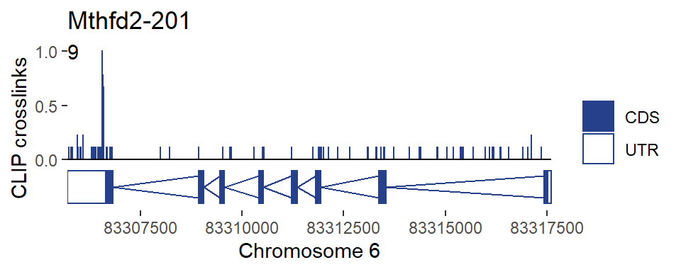

```r
plot_CLIP_profile("Mthfd2-201")
```

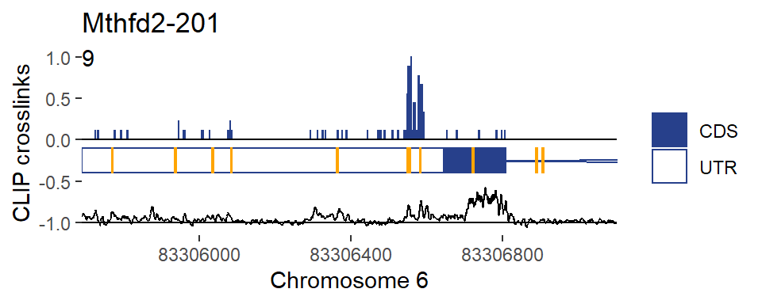

```r
ggsave("Figure_panels/FigS3A_Mthfd2CLIP_complete.pdf")
plot_CLIP_profile("Mthfd2-201", zoom_max = 83307100, displayTATT = T, consPlot = T)
```

```r
ggsave("Figure_panels/FigS3A_Mthfd2CLIP_3UTR.pdf")
```

### Mat2a

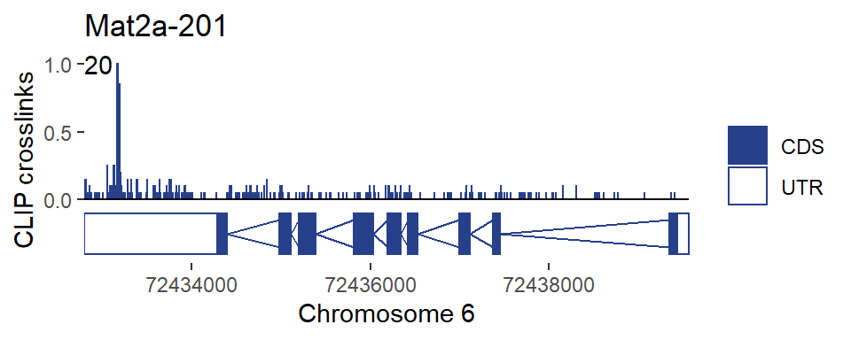

```r
plot_CLIP_profile("Mat2a-201")
```

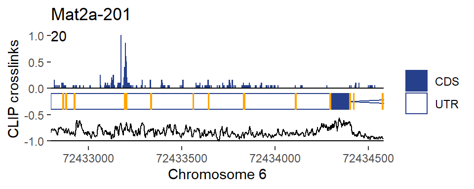

```r
ggsave("Figure_panels/FigS3B_Mat2aCLIP_complete.pdf")
plot_CLIP_profile("Mat2a-201", zoom_max = 72434580, displayTATT = T, consPlot = T)
```

```r
ggsave("Figure_panels/FigS3B_Mat2aCLIP_3UTR.pdf")
```

## Figure S3E

### Idh3a

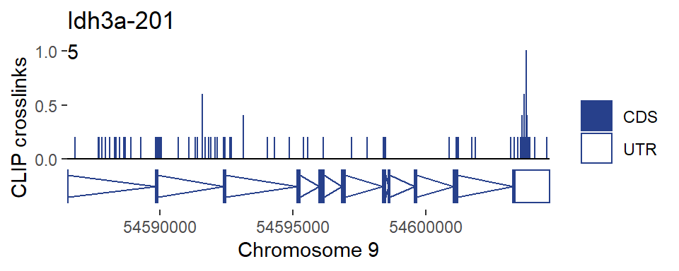

```r
plot_CLIP_profile("Idh3a-201")
```

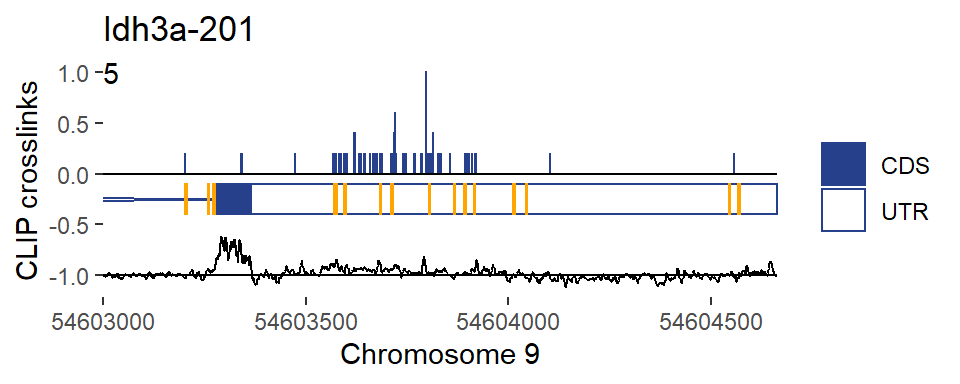

```r
ggsave("Figure_panels/FigS3E_Idh3aCLIP_complete.pdf")
plot_CLIP_profile("Idh3a-201", zoom_min = 54603000, displayTATT = T, consPlot = T)
```

```r
ggsave("Figure_panels/FigS3E_Idh3aCLIP_3UTR.pdf")
```

### Ogdh

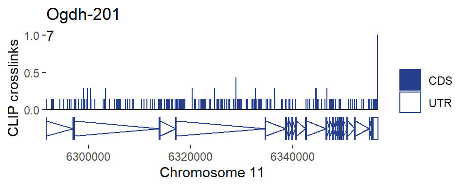

```r
plot_CLIP_profile("Ogdh-201")
```

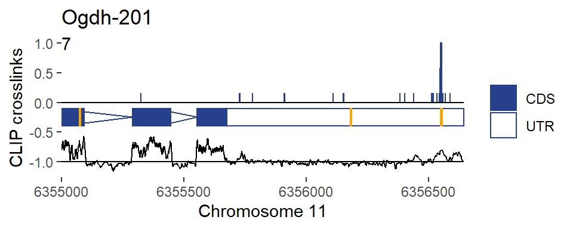

```r
ggsave("Figure_panels/FigS3E_OgdhCLIP_complete.pdf")
plot_CLIP_profile("Ogdh-201", zoom_min = 6355000, displayTATT = T, consPlot = T)
```

```r
ggsave("Figure_panels/FigS3E_OgdhCLIP_3UTR.pdf")
```

### Mdh2

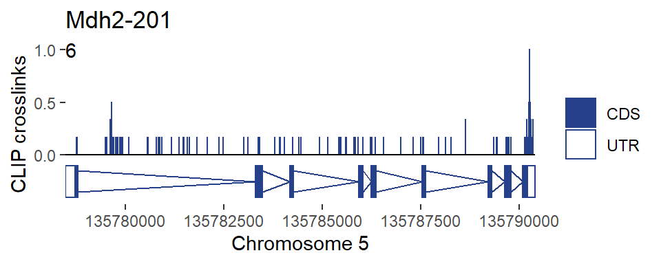

```r
plot_CLIP_profile("Mdh2-201")
```

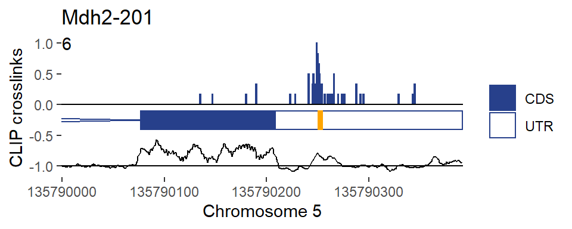

```r
ggsave("Figure_panels/FigS3E_Mdh2CLIP_complete.pdf")
plot_CLIP_profile("Mdh2-201", zoom_min = 135790000, displayTATT = T, consPlot = T)
```

```r
ggsave("Figure_panels/FigS3E_Mdh2CLIP_3UTR.pdf")
```

### Got1

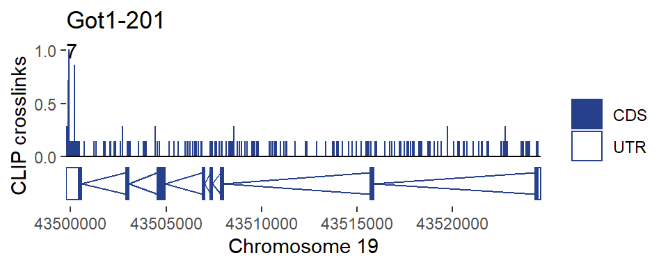

```r
plot_CLIP_profile("Got1-201")
```

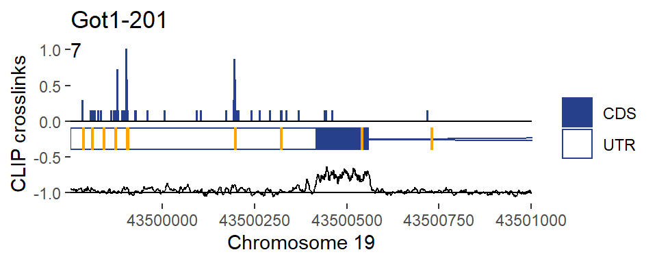

```r
ggsave("Figure_panels/FigS3E_Got1CLIP_complete.pdf")
plot_CLIP_profile("Got1-201", zoom_max = 43501000, displayTATT = T, consPlot = T)
```

```r
ggsave("Figure_panels/FigS3E_Got1CLIP_3UTR.pdf")
```

### Acly

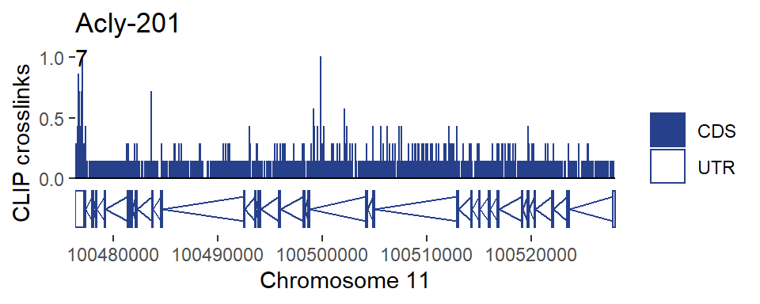

```r
plot_CLIP_profile("Acly-201")
```

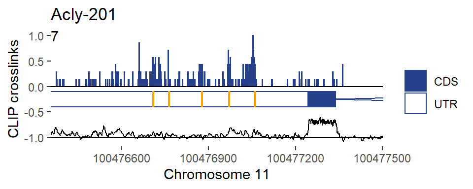

```r
ggsave("Figure_panels/FigS3E_AclyCLIP_complete.pdf")
plot_CLIP_profile("Acly-201", zoom_max = 100477500, displayTATT = T, consPlot = T)
```

```r
ggsave("Figure_panels/FigS3E_AclyCLIP_3UTR.pdf")
```

### Pank3

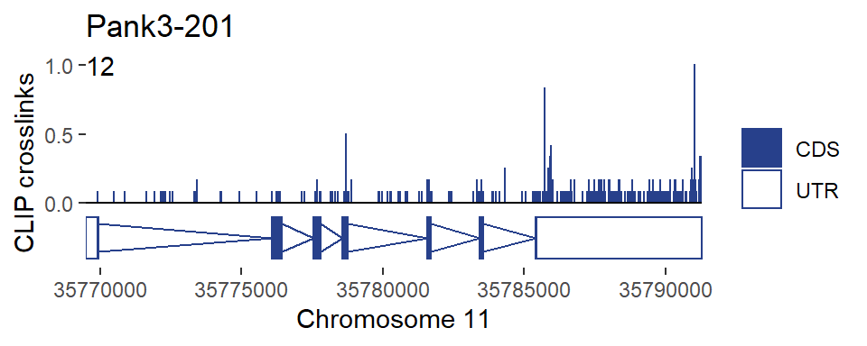

```r
plot_CLIP_profile("Pank3-201")
```

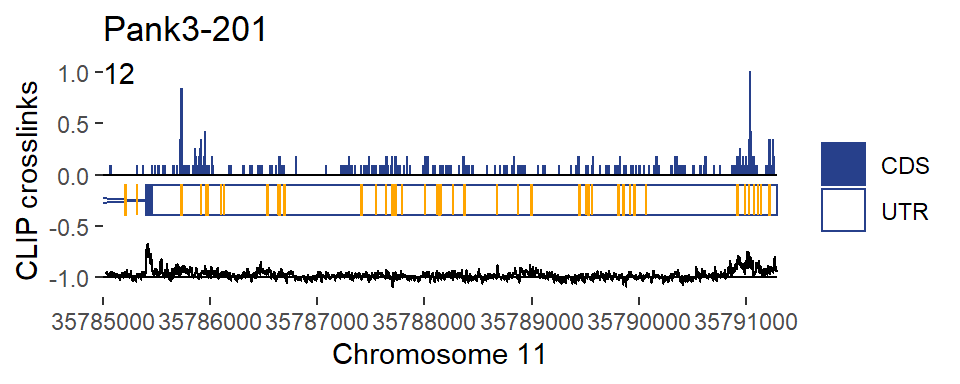

```r
ggsave("Figure_panels/FigS3E_Pank3CLIP_complete.pdf")
plot_CLIP_profile("Pank3-201", zoom_min = 35785000, displayTATT = T, consPlot = T)
```

```r
ggsave("Figure_panels/FigS3E_Pank3CLIP_3UTR.pdf")
```

### Fasn

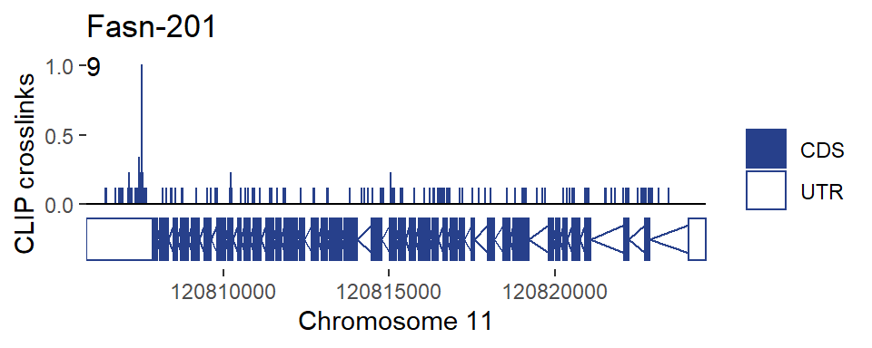

```r
plot_CLIP_profile("Fasn-201")
```

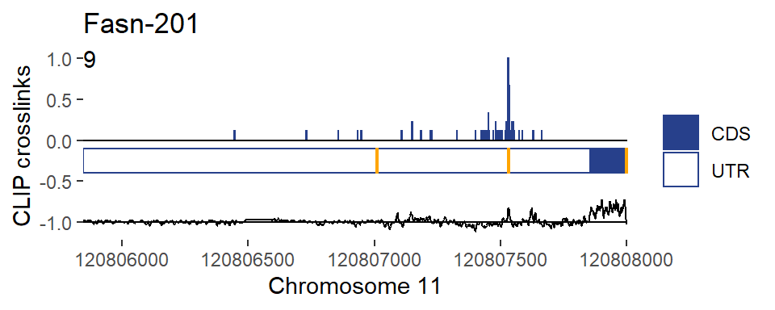

```r
ggsave("Figure_panels/FigS3E_FasnCLIP_complete.pdf")
plot_CLIP_profile("Fasn-201", zoom_max = 120808000, displayTATT = T, consPlot = T)
```

```r
ggsave("Figure_panels/FigS3E_FasnCLIP_3UTR.pdf")
```

### Hmgcr

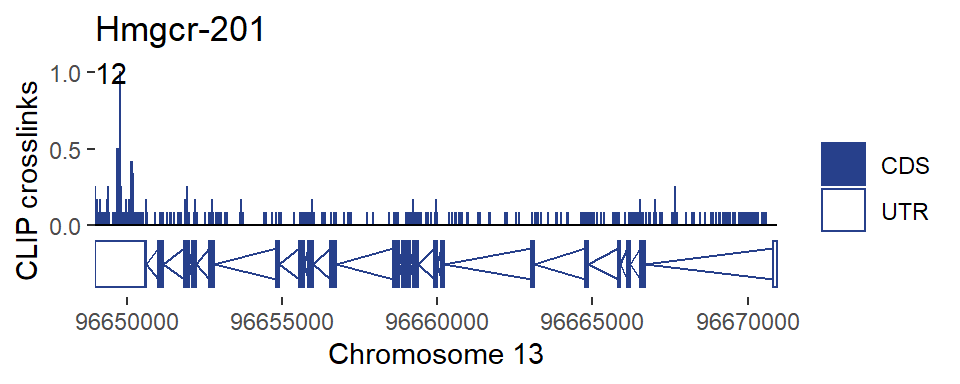

```r
plot_CLIP_profile("Hmgcr-201")
```

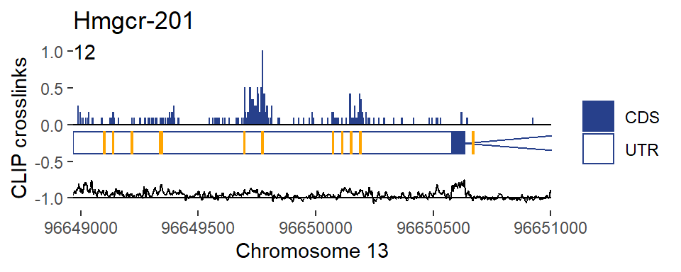

```r
ggsave("Figure_panels/FigS3E_HmgcrCLIP_complete.pdf")
plot_CLIP_profile("Hmgcr-201", zoom_max = 96651000, displayTATT = T, consPlot = T)
```

```r
ggsave("Figure_panels/FigS3E_HmgcrCLIP_3UTR.pdf")
```

## Figure 5A-C

### Gls

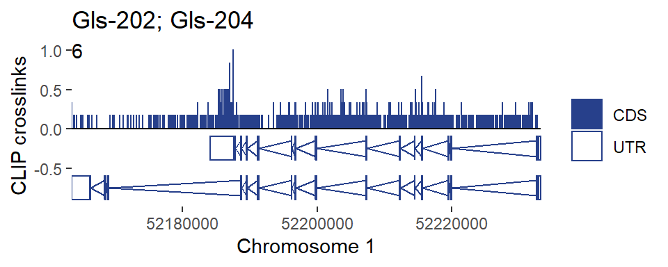

```r
plot_CLIP_profile(c("Gls-202", "Gls-204"))
```

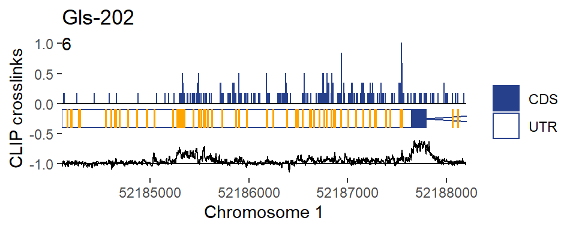

```r
ggsave("Figure_panels/Fig5A_GlsCLIP_complete.pdf")
plot_CLIP_profile(c("Gls-202"), zoom_max = 52188200, displayTATT = T, consPlot = T)
```

```r
ggsave("Figure_panels/Fig5A_GlsCLIP_3UTR.pdf")
```

### Glud1

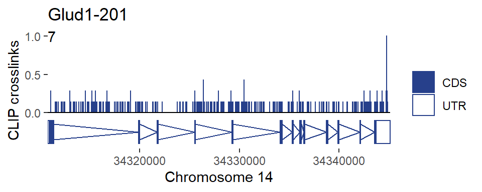

```r
plot_CLIP_profile("Glud1-201")
```

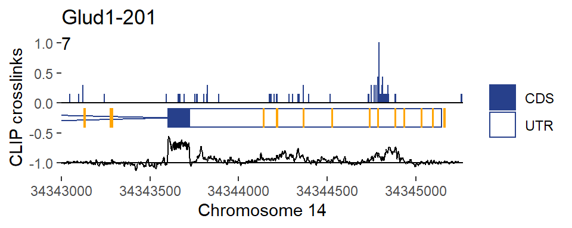

```r
ggsave("Figure_panels/Fig5B_Glud1CLIP_complete.pdf")
plot_CLIP_profile("Glud1-201", zoom_min = 34343000, zoom_max = 34345265, displayTATT = T, consPlot = T)
```

```r
ggsave("Figure_panels/Fig5B_Glud1CLIP_3UTR.pdf")
```

### Slc38a2

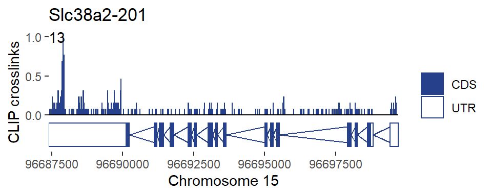

```r
plot_CLIP_profile("Slc38a2-201")
```

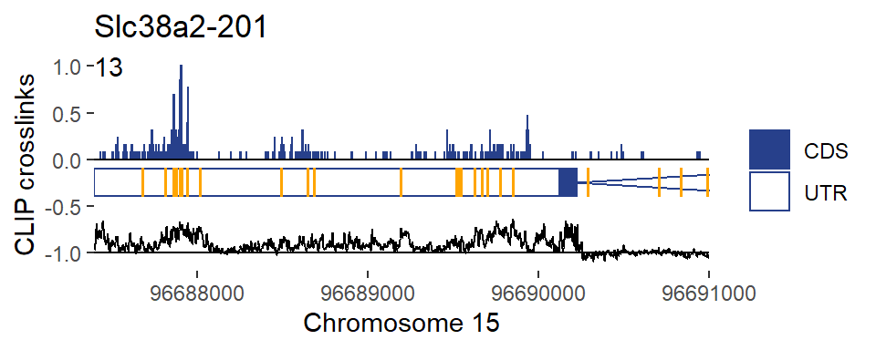

```r
ggsave("Figure_panels/Fig5C_Slc38a2CLIP_complete.pdf")
plot_CLIP_profile("Slc38a2-201", zoom_max = 96691000, displayTATT = T, consPlot = T)
```

```r
ggsave("Figure_panels/Fig5C_Slc38a2CLIP_3UTR.pdf")
```

## Figure S5E

### Gzmb

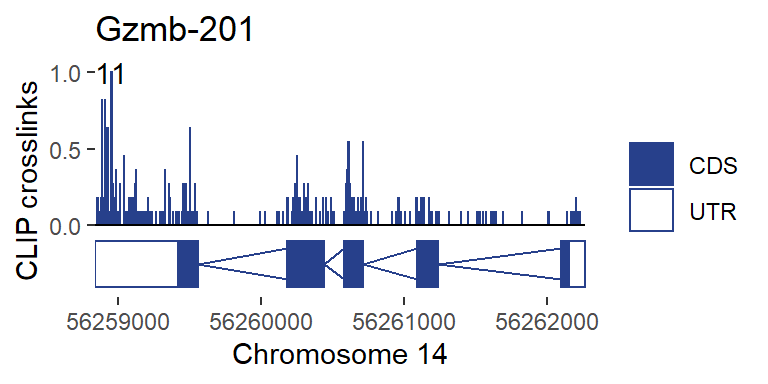

```r
plot_CLIP_profile("Gzmb-201")
```

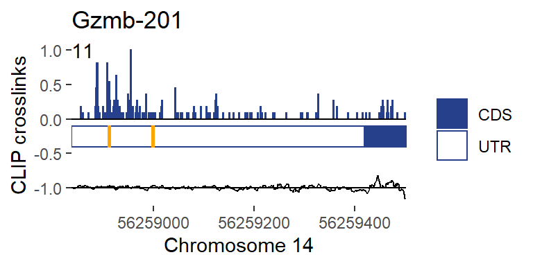

```r
ggsave("Figure_panels/FigS5E_GzmbCLIP_complete.pdf")
plot_CLIP_profile("Gzmb-201", zoom_max = 56259500, displayTATT = T, consPlot = T)
```

```r
ggsave("Figure_panels/FigS5E_GzmbCLIP_3UTR.pdf")
```

### Tbx21

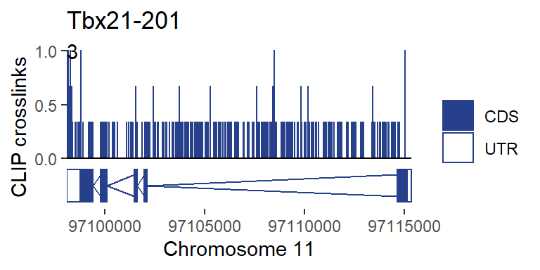

```r
plot_CLIP_profile("Tbx21-201")
```

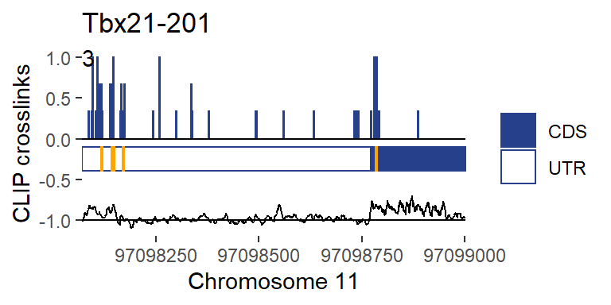

```r
ggsave("Figure_panels/FigS5E_Tbx21CLIP_complete.pdf")
plot_CLIP_profile("Tbx21-201", zoom_max = 97099000, displayTATT = T, consPlot = T)
```

```r
ggsave("Figure_panels/FigS5E_Tbx21CLIP_3UTR.pdf")
```

### Hopx

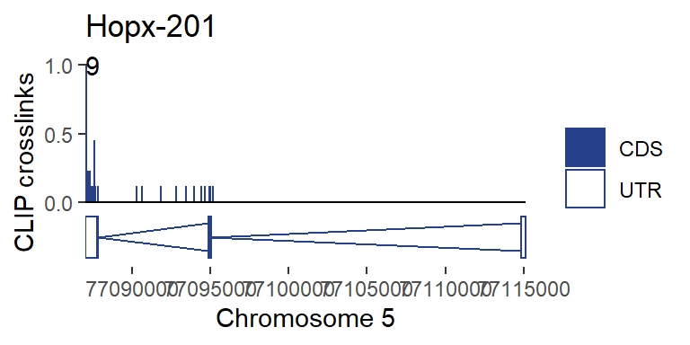

```r
plot_CLIP_profile("Hopx-201")
```

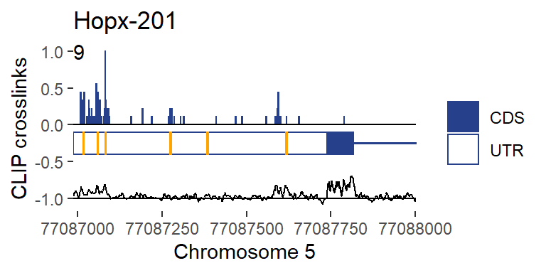

```r
ggsave("Figure_panels/FigS5E_HopxCLIP_complete.pdf")
plot_CLIP_profile("Hopx-201", zoom_max = 77088000, displayTATT = T, consPlot = T)
```

```r
ggsave("Figure_panels/FigS5E_HopxCLIP_3UTR.pdf")
```

## Sequence conservation (Fig S2, S3, 5)

For sequence conservation plots, orthologues were identified and 3’UTR sequences extracted using biomart, where possible, or manually if orthologues/equivalent 3’UTRs were not annotated. Alignment of the whole 3’UTR was then done with kalign, before extracting the portion corresponding to the ARE(s), and TATT motifs highlighted manually in Illustrator.

# Figure 3A, 4A, 6A - metabolism heatmaps

Heatmaps for transcriptomics and metabolomics were each made as one large heatmap for figures 3, 4, 6, with gaps separating the different pathways. For transcriptomics, dummy rows were included to ensure scales are the same as for the heatmap in figure 7, and the heatmap was split into the separate figures in Illustrator.

Rate-limiting genes will be highlighted in bold/red in Illustrator

## Transcriptomics

```r
read_tsv("metabolomics/genes_for_overall_metabolism_hm.txt", col_names = "Gene") %>%
  mutate(Nascent_zscore = all_L2FC_norm$Nascent_zscore[match(Gene, all_L2FC_norm$Gene)]) %>%
  mutate(Stability_zscore = all_L2FC_norm$Stability_zscore[match(Gene, all_L2FC_norm$Gene)]) %>%
  mutate(RNA_zscore = all_L2FC_norm$RNA_zscore[match(Gene, all_L2FC_norm$Gene)]) %>%
  mutate(Ribo_zscore = all_L2FC_norm$Ribo_zscore[match(Gene, all_L2FC_norm$Gene)]) %>%
    mutate(Nascent_padj = res_4sU$padj[match(Gene, res_4sU$Gene)]) %>%
    mutate(Stability_padj = Stability_differences$fdr.value[match(Gene, Stability_differences$Gene)]) %>%
    mutate(RNA_padj = res_RNA$padj[match(Gene, res_RNA$Gene)]) %>%
    mutate(Ribo_padj = res_Ribo$padj[match(Gene, res_Ribo$Gene)]) %>%
      mutate(Nascent_pval = res_4sU$pvalue[match(Gene, res_4sU$Gene)]) %>%
      mutate(Stability_pval = Stability_differences$p.value[match(Gene, Stability_differences$Gene)]) %>%
      mutate(RNA_pval = res_RNA$pvalue[match(Gene, res_RNA$Gene)]) %>%
      mutate(Ribo_pval = res_Ribo$pvalue[match(Gene, res_Ribo$Gene)]) %>%
        mutate(RNA_Ctrl_expression = norm_counts_RNA$Ctrl_mean[match(Gene, norm_counts_RNA$Gene)]) %>%
          mutate(Darnell_72h_3UTR_sum_n90 = if_else(Gene %in% CLIP_72h_3UTR_sum$Gene_name, CLIP_72h_3UTR_sum$sum_3UTR_72h_n90[match(Gene, CLIP_72h_3UTR_sum$Gene_name)], 0)) %>%
          mutate(iCLIP_24h_3UTR_sum_n90 = if_else(Gene %in% iCLIP_24h_3UTR_sum$Gene_name, iCLIP_24h_3UTR_sum$sum_3UTR_24h_n90[match(Gene, iCLIP_24h_3UTR_sum$Gene_name)], 0)) %>%
          mutate(Darnell_4h_3UTR_sum_n90 = if_else(Gene %in% CLIP_4h_3UTR_sum$Gene_name, CLIP_4h_3UTR_sum$sum_3UTR_4h_n90[match(Gene, CLIP_4h_3UTR_sum$Gene_name)], 0)) -> Metabolism_RNA_hm
summary(Metabolism_RNA_hm)
```

```
##      Gene           Nascent_zscore    Stability_zscore    RNA_zscore
##  Length:92          Min.   :-1.5138   Min.   :-2.2616   Min.   :-1.0490
##  Class :character   1st Qu.:-0.3141   1st Qu.:-0.4918   1st Qu.: 0.1215
##  Mode  :character   Median : 0.3165   Median : 0.1715   Median : 0.8593
##                     Mean   : 0.4854   Mean   : 0.1844   Mean   : 0.7831
##                     3rd Qu.: 1.1858   3rd Qu.: 0.6592   3rd Qu.: 1.3915
##                     Max.   : 3.6502   Max.   : 2.8321   Max.   : 2.9478
##   Ribo_zscore       Nascent_padj     Stability_padj      RNA_padj
##  Min.   :-1.7316   Min.   :0.03532   Min.   :0.2191   Min.   :0.0000000
##  1st Qu.:-0.3061   1st Qu.:0.99963   1st Qu.:0.4996   1st Qu.:0.0000000
##  Median : 0.3297   Median :0.99963   Median :0.4996   Median :0.0003137
##  Mean   : 0.3906   Mean   :0.92618   Mean   :0.4894   Mean   :0.1725340
##  3rd Qu.: 0.9928   3rd Qu.:0.99963   3rd Qu.:0.4996   3rd Qu.:0.2635151
##  Max.   : 3.3177   Max.   :0.99963   Max.   :0.4996   Max.   :0.9928886
##    Ribo_padj          Nascent_pval       Stability_pval        RNA_pval
##  Min.   :0.0000001   Min.   :0.0002594   Min.   :0.002312   Min.   :0.0000000
##  1st Qu.:0.2498464   1st Qu.:0.1694969   1st Qu.:0.143887   1st Qu.:0.0000000
##  Median :0.5231438   Median :0.4893200   Median :0.284454   Median :0.0000521
##  Mean   :0.5161553   Mean   :0.4714817   Mean   :0.259089   Mean   :0.1346426
##  3rd Qu.:0.7987566   3rd Qu.:0.7618746   3rd Qu.:0.372762   3rd Qu.:0.1478587
##  Max.   :0.9846240   Max.   :0.9796504   Max.   :0.496934   Max.   :0.9873143
##    Ribo_pval       RNA_Ctrl_expression Darnell_72h_3UTR_sum_n90
##  Min.   :0.00000   Min.   : 6.388      Min.   :0.00000
##  1st Qu.:0.03219   1st Qu.:10.574      1st Qu.:0.00000
##  Median :0.17567   Median :11.729      Median :0.01838
##  Mean   :0.30293   Mean   :11.556      Mean   :0.47408
##  3rd Qu.:0.51768   3rd Qu.:12.590      3rd Qu.:0.47181
##  Max.   :0.94950   Max.   :15.497      Max.   :5.64951
##  iCLIP_24h_3UTR_sum_n90 Darnell_4h_3UTR_sum_n90
##  Min.   :0.00000        Min.   :0.0000
##  1st Qu.:0.00000        1st Qu.:0.0000
##  Median :0.05357        Median :0.0000
##  Mean   :0.35132        Mean   :0.4164
##  3rd Qu.:0.29464        3rd Qu.:0.3182
##  Max.   :5.03571        Max.   :4.4727
```

Range of 0-20 for CLIP and 5-16 for expression (taking into account TFs in figure 7 - keep them the same)

```r
Metabolism_RNA_hm %>%
  add_row(Gene ="dummy", Nascent_zscore = 0, Stability_zscore = 0, RNA_zscore =0, Ribo_zscore =0, Darnell_4h_3UTR_sum_n90 = 20, Darnell_72h_3UTR_sum_n90 =20, iCLIP_24h_3UTR_sum_n90 =20, RNA_Ctrl_expression = 5) %>%
  add_row(Gene ="dummy2", Nascent_zscore = 0, Stability_zscore = 0, RNA_zscore =0, Ribo_zscore =0, Darnell_4h_3UTR_sum_n90 = 0, Darnell_72h_3UTR_sum_n90 =0, iCLIP_24h_3UTR_sum_n90 =0, RNA_Ctrl_expression = 16) -> Metabolism_RNA_hm
```

Separate out into z scores for main heatmap, annotations, and p values - convert these to stars depending on significance.

Symmetrical breaks for main colour scale will be the same as those used for TFs.

For CLIP annotations - log transform values.

```r
Metabolism_RNA_hm %>%
  select(1:5) %>%
  column_to_rownames("Gene") ->
    Metabolism_RNA_zscores


Metabolism_RNA_hm %>%
  mutate(Nascent_sig = case_when(
    Nascent_padj < 0.05 ~ "***",
    Nascent_pval < 0.05 ~ "**",
    Nascent_pval < 0.1 ~ "*",
    TRUE ~ ""
  )) %>%
  mutate(Stability_sig = case_when(
    Stability_padj < 0.05 ~ "***",
    Stability_pval < 0.05 ~ "**",
    Stability_pval < 0.1 ~ "*",
    TRUE ~ ""
  )) %>%
  mutate(RNA_sig = case_when(
    RNA_padj < 0.05 ~ "***",
    RNA_pval < 0.05 ~ "**",
    RNA_pval < 0.1 ~ "*",
    TRUE ~ ""
  )) %>%
  mutate(Ribo_sig = case_when(
    Ribo_padj < 0.05 ~ "***",
    Ribo_pval < 0.05 ~ "**",
    Ribo_pval < 0.1 ~ "*",
    TRUE ~ ""
  )) %>%
  select(Gene, ends_with("sig")) %>%
  column_to_rownames("Gene") -> Metabolism_RNA_sig


Metabolism_RNA_hm %>%
  select(Gene, RNA_Ctrl_expression, ends_with("n90")) %>%
  mutate_at(vars(ends_with("n90")), function(x) log2((10*x)+1)) %>%
  column_to_rownames("Gene") -> Metabolism_RNA_annotations
```

Plot heatmap:

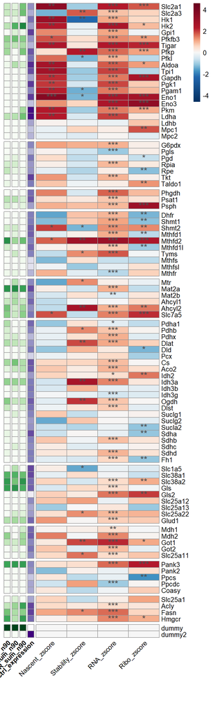

```r
sym_breaks <- seq(-4.6, 4.6, length.out = 401)

#pdf("Figure_panels/Fig3A_4A_RNA_hm.pdf", height = 15, width = 4.5)
Metabolism_RNA_zscores %>%
  pheatmap(cluster_rows = F,
           cluster_cols = F,
           breaks = sym_breaks,
           angle_col = 45,
           fontsize_row = 10,
           color = c(colorRampPalette(colors = brewer.pal(11,"RdBu")[11:10])(100),colorRampPalette(colors = brewer.pal(11,"RdBu")[10:2])(200),colorRampPalette(colors = brewer.pal(11,"RdBu")[2:1])(100)),
           display_numbers = Metabolism_RNA_sig,
           annotation_row = Metabolism_RNA_annotations,
           annotation_colors = list(
             Darnell_72h_3UTR_sum_n90 = brewer.pal(9, "Greens"),
             Darnell_4h_3UTR_sum_n90 = brewer.pal(9, "Greens"),
             iCLIP_24h_3UTR_sum_n90 = brewer.pal(9, "Greens"),
             RNA_Ctrl_expression = brewer.pal(9, "Purples")
           ),
           fontsize_number = 14,
           annotation_legend = F,
           gaps_row = c(21, 28, 31, 41, 47, 69, 78, 83, 88, 92))
```

```r
#dev.off()
```

## Metabolomics

Heatmap is generated from the LCMS data (without glucose or glutamine tracing)

Results were first collated in Excel, raw values normalised to the total metabolite abundance for each sample, and p values calcuated by unpaired, two-tailed t-test.

```r
read_tsv("metabolomics/collated_metabolomics_JWest_norm_total_metabolites.txt") ->
  all_metabolomics_LCMS
all_metabolomics_LCMS %>%
  select(2:14) %>%
  column_to_rownames("Metabolite") %>%
  log2() ->
    all_metabolites_total_scaled

all_metabolites_total_scaled - rowMeans(all_metabolites_total_scaled) -> all_metabolites_total_scaled

sym_breaks_met_total <- seq(-max(abs(all_metabolites_total_scaled)), max(abs(all_metabolites_total_scaled)), length.out = 101)

all_metabolomics_LCMS %>%
  mutate(Ctrl_mean = if_else(grepl("oA", Metabolite), NA_real_, log2(rowMeans(select(all_metabolomics_LCMS, starts_with("WT")))))) ->
  all_metabolomics_LCMS
all_metabolomics_LCMS %>%
  select(2, P_value, Ctrl_mean) %>%
    mutate(P_value = case_when(
      P_value < 0.05 ~ "p < 0.05",
      P_value < 0.1 ~ "p < 0.1",
      TRUE ~ "n.s."
    )) %>%
    column_to_rownames("Metabolite") ->
      met_annotations_total
```

Plot data:

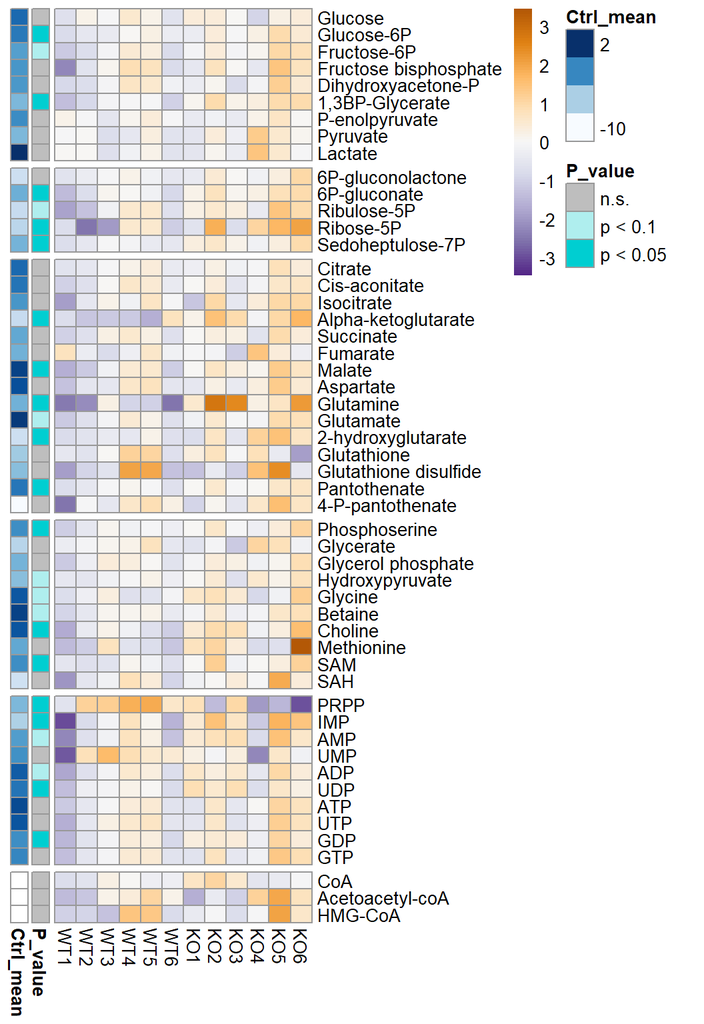

```r
#pdf("Figure_panels/Fig6A_met_hm.pdf", height=8, width =5.5, useDingbats = F)
all_metabolites_total_scaled %>%
  pheatmap(cluster_rows = F,
           cluster_cols = F,
           color = colorRampPalette(rev(brewer.pal(11,"PuOr")[2:10]))(100),
           breaks = sym_breaks_met_total,
           annotation_row = met_annotations_total,
           annotation_colors = list(
             P_value = c(n.s. = "grey", "p < 0.1" = "paleturquoise", "p < 0.05" = "darkturquoise"),
             Ctrl_mean = brewer.pal(9,"Blues")
             ),
           gaps_row = c(9,14,29,39, 49))
```

```r
#dev.off()
```

Calculate fold change (non-log transformed) and export for supplementary table

### Table S10 - LC-MS

```r
all_metabolomics_LCMS %>%
  mutate(Ctrl_mean_lin = rowMeans(select(all_metabolomics_LCMS, starts_with("WT")))) %>%
  mutate(dKO_mean_lin = rowMeans(select(all_metabolomics_LCMS, starts_with("KO")))) %>%
  mutate(fold_change = dKO_mean_lin/Ctrl_mean_lin) %>%
  write_tsv("Supplementary_tables/TableS10_LCMS.txt") # then delete the columns I don't want in excel
```

# Figure S4A - LC-MS

For some of the glutamine/TCA related metabolites, I will also include bar plots (with points) to make trend clearer

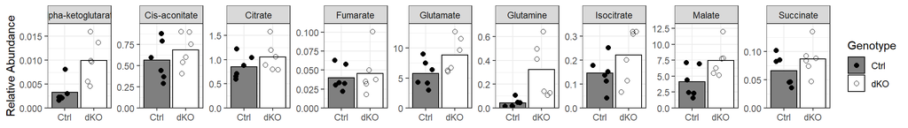

```r
all_metabolomics_LCMS %>%
  pivot_longer(c(starts_with("WT"), starts_with("KO")), names_to = "Sample", values_to = "Abundance") %>%
  mutate(Genotype = if_else(grepl("WT", Sample), "Ctrl", "dKO")) %>%
  filter(Symbol %in% c("Gln", "Glu", "AKG", "Citrate", "Aco", "Isocitrate", "SUC", "FUM", "Mal")) %>%
  ggplot(aes(x = Genotype, y = Abundance, shape = Genotype, fill = Genotype)) +
    stat_summary(geom = "bar", fun = mean, colour = "black") +
    geom_jitter(height = 0, width = 0.3, size = 2) +
    facet_wrap(~Metabolite, scales = "free", nrow = 1) +
    scale_fill_manual(values = c("grey50", "white")) +
    scale_shape_manual(values = c(16,1)) +
    theme_bw() +
    scale_y_continuous(expand = expansion(mult = c(0,0.1))) +
    labs(x = NULL, y = "Relative Abundance") +
    theme(panel.background = element_blank(), plot.background = element_blank(), legend.key = element_blank(), legend.background = element_blank())
```

```r
ggsave("Figure_panels/FigS4A_LCMS_bar.pdf")
```

# Figures 3B and 4B - dotplot for Ribo-seq/CLIP

For the same genes as included in the heatmap, want a dotplot where the colour for each gene represents its z-score in Riboseq, and diamonds around the outside represent CLIP binding (sum of reads in 72h dataset - no need to norm to 90th percentile in this case since just one dataset, can show absolute scale).

These will then be used and moved round in Illustrator to create pathway figures.

```r
Metabolism_RNA_hm %>%
  left_join(CLIP_72h_3UTR_sum, by = c("Gene" = "Gene_name")) %>%
  mutate(sum_3UTR_72h = if_else(is.na(sum_3UTR_72h), 0, sum_3UTR_72h)) -> Metabolism_RNA_hm
```

There are 94 rows in the dataframe - last 2 are ‘dummy’ which we don’t need here - plot in a 10x10 grid.

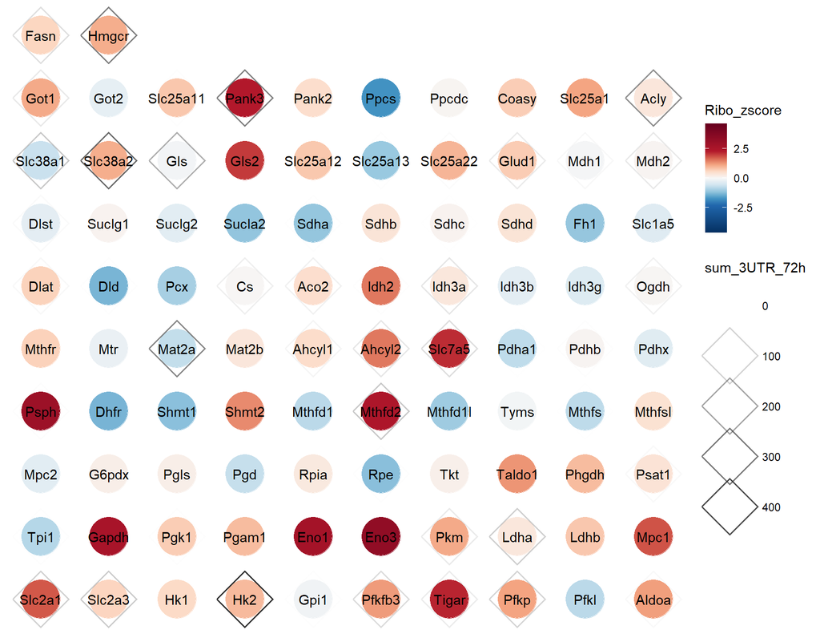

```r
Metabolism_RNA_hm %>%
  add_column(y_offset = c(rep(1,10), rep(2, 10), rep(3,10), rep(4,10), rep(5,10), rep(6, 10), rep(7,10), rep(8,10), rep(9,10), rep(10,2), NA, NA)) %>%
  add_column(x_offset = c(rep(seq(1,10), 9), 1, 2, NA, NA)) %>%
  ggplot(aes(x_offset, y_offset))  +
    geom_point(aes(colour = Ribo_zscore), size = 14) +
    scale_colour_gradientn(colours = c(colorRampPalette(colors = brewer.pal(11,"RdBu")[11:10])(100),colorRampPalette(colors = brewer.pal(11,"RdBu")[10:2])(200),colorRampPalette(colors = brewer.pal(11,"RdBu")[2:1])(100)),
                           limits = c(-4.6, 4.6)) +
    geom_text(aes(label = Gene)) +
    geom_point(aes(alpha = sum_3UTR_72h), colour= "grey20", shape = 5, size = 14, stroke = 1) +
    scale_alpha_continuous(range =c(0,1)) +
    theme(axis.line = element_blank(), axis.ticks = element_blank(), axis.title = element_blank(), axis.text = element_blank())
```

```r
ggsave("Figure_panels/Fig3B_4B_dotplot.pdf", useDingbats = F)
```

# Figure S3F: sKO vs dKO for metabolic genes

Heatmap showing z-scores for a selection of metabolic genes in sKO and dKO cells

```r
tibble(Gene = c("Myc", "Hif1a", "Hk2", "Pfkfb3", "Slc2a1", "Slc2a3", "Pfkp", "Mthfd2", "Mat2a", "Slc38a2", "Gls", "Glud1", "Idh3a", "Ogdh", "Mdh2", "Got1", "Acly", "Pank3", "Hmgcr", "Fasn")) %>%
  left_join(sdKO_zscores_pvals) -> sdKO_metabolism
sdKO_metabolism %>%
  column_to_rownames("Gene") %>%
  select(starts_with("z.score")) -> sdKO_met_hm

sdKO_metabolism %>%
  mutate(TTP_sig = case_when(
    deseq_padj_TTP < 0.05 ~ "***",
    deseq_pval_TTP < 0.05 ~ "**",
    deseq_pval_TTP < 0.1 ~ "*",
    TRUE ~ ""
  )) %>%
  mutate(Tis11b_sig = case_when(
    deseq_padj_Tis11b < 0.05 ~ "***",
    deseq_pval_Tis11b < 0.05 ~ "**",
    deseq_pval_Tis11b < 0.1 ~ "*",
    TRUE ~ ""
  )) %>%
  mutate(dKO_sig = case_when(
    deseq_padj_dKO < 0.05 ~ "***",
    deseq_pval_dKO < 0.05 ~ "**",
    deseq_pval_dKO < 0.1 ~ "*",
    TRUE ~ ""
  )) %>%
  column_to_rownames("Gene") %>%
  select(ends_with("sig")) -> sdKO_met_pval
```

Plot heatmap:

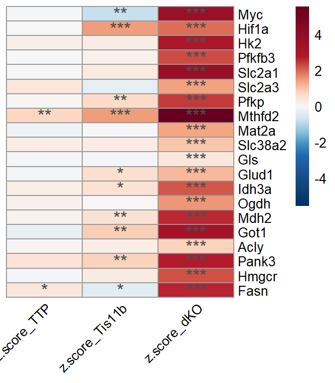

```r
sdKO_breaks = seq(-max(abs(sdKO_met_hm)), max(abs(sdKO_met_hm)), length.out = 401)

#pdf("Figure_panels/FigS3F_sdKO_heatmap_metabolism.pdf", height = 4, width = 3.5)
sdKO_met_hm %>%
  pheatmap(cluster_rows = F,
           cluster_cols = F,
           breaks = sdKO_breaks,
           angle_col = 45,
           fontsize_row = 10,
           color = c(colorRampPalette(colors = brewer.pal(11,"RdBu")[11:10])(100),colorRampPalette(colors = brewer.pal(11,"RdBu")[10:2])(200),colorRampPalette(colors = brewer.pal(11,"RdBu")[2:1])(100)),
           display_numbers = sdKO_met_pval,
           fontsize_number = 14,
           annotation_legend = F)
```

```r
#dev.off()
```

# Figure 5G-I - rate-limiting genes

Made lists of genes encoding rate limiting enzymes/transporters in metabolic pathways

Classified a gene as rate limiting if either described by at least 2 references as being rate limiting, or supported by a single reference in which it is demonstrated to be so. (Tried filtering against list of genes from RLEdb but this classes almost everything as rate limiting!)

Need to convert these into lists of ensembl IDs.

```r
read_tsv("metabolomics/rate_limiting2.txt") %>%
  filter(!is.na(Rate_limiting)) -> rateLim_genes
rateLim_genes %>%
  filter(Rate_limiting == T) %>%
  pull(Gene_ID) %>%
  write("metabolomics/rateLim2_ID.txt")

rateLim_genes %>%
  filter(Rate_limiting == F) %>%
  pull(Gene_ID) %>%
  write("metabolomics/nonRateLim2_ID.txt")
```

## Enrichment for CLIP targets

Ran CLIP enrichment pipeline for each of the CLIP datasets with each list, eg: Rscript –vanilla expression_match_iCLIP.R rateLim_ID.txt CLIP_4h_exMatch.RData

Read in outputs and collate into a single dataframe:

```r
list(
  readRDS("metabolomics/rateLim2_ID_CLIP_4h_exMatch_expressionMatch_processed_data.rds") %>%
  sapply(function(x) add_column(x, datasets = "rateLim_4h")),
  readRDS("metabolomics/nonRateLim2_ID_CLIP_4h_exMatch_expressionMatch_processed_data.rds") %>%
  sapply(function(x) add_column(x, datasets = "nonRateLim_4h")),
  readRDS("metabolomics/rateLim2_ID_iCLIP_24h_exMatch_expressionMatch_processed_data.rds") %>%
  sapply(function(x) add_column(x, datasets = "rateLim_24h")),
  readRDS("metabolomics/nonRateLim2_ID_iCLIP_24h_exMatch_expressionMatch_processed_data.rds") %>%
  sapply(function(x) add_column(x, datasets = "nonRateLim_24h")),
  readRDS("metabolomics/rateLim2_ID_CLIP_72h_exMatch_expressionMatch_processed_data.rds") %>%
  sapply(function(x) add_column(x, datasets = "rateLim_72h")),
  readRDS("metabolomics/nonRateLim2_ID_CLIP_72h_exMatch_expressionMatch_processed_data.rds") %>%
  sapply(function(x) add_column(x, datasets = "nonRateLim_72h"))
) -> all_rate_lim2_CLIPenr



tibble(Datasets=sapply(all_rate_lim2_CLIPenr, function(x) x[[1]][1,"datasets"]),
       Total_overlaps=sapply(all_rate_lim2_CLIPenr, function(x) sum(x[[1]]$iCLIP_hit)),
       ExMatch_median=sapply(all_rate_lim2_CLIPenr, function(x) median(x[[2]]$Overlap)),
       ExMatch_q95=sapply(all_rate_lim2_CLIPenr, function(x) x[[2]][1,2]),
       ExMatch_q5=sapply(all_rate_lim2_CLIPenr, function(x) x[[2]][1,3])) %>%
  mutate(Overlap_enrichment = Total_overlaps/ExMatch_median) %>%
  mutate(q5_enrichment = ExMatch_q5/ExMatch_median) %>%
  mutate(q95_enrichment = ExMatch_q95/ExMatch_median) %>%
  separate(Datasets, c("Type", "CLIPdata")) %>%
  mutate(CLIPdata = factor(CLIPdata, levels = c("4h", "24h", "72h"))) -> summary_ratelim2_CLIP
```

### Plot data

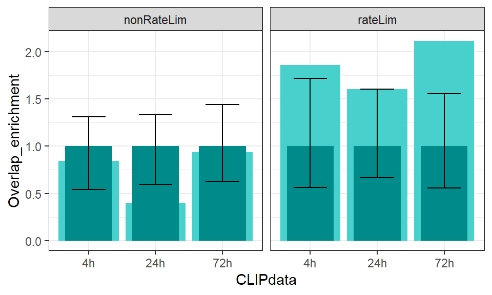

```r
summary_ratelim2_CLIP %>%
  ggplot(aes(x = CLIPdata, y = Overlap_enrichment)) +
    geom_col(fill = "mediumturquoise") +
    geom_col(aes(y = 1), fill = "darkcyan", width=0.7) +
    geom_errorbar(aes(ymin = q5_enrichment, ymax = q95_enrichment), width=0.5) +
    facet_grid(~ Type) +
    theme_bw() +
    theme(panel.background = element_blank(), plot.background = element_blank())
```

```r
ggsave("Figure_panels/Fig5G_Rate_limiting_CLIP_enrich_v2.pdf")
```

## ARE enrichment

Just for exMatched with 72h CLIP data - ran through TATT analysis pipeline, eg: Rscript –vanilla TATT_analysis.R rateLim_ID_CLIP_72h_exMatch_expression_matched.txt Mus_musculus.GRCm38.90.gtf

### Collate and plot data

```r
read_tsv("metabolomics/TATT_rateLim2_ID_CLIP_72h_exMatch_expression_matched.txt") %>%
  filter(Type != "Random") %>%
  group_by(Type, Gene_set) %>%
  summarise(TATTTATT = sum(nTATTTATT > 0)) %>%
  summarise(median = median(TATTTATT), q5 = quantile(TATTTATT, 0.05), q95 = quantile(TATTTATT, 0.95)) %>%
  add_column(rateLim = "RateLim") -> TATTTATT_ratelim2
read_tsv("metabolomics/TATT_nonRateLim2_ID_CLIP_72h_exMatch_expression_matched.txt") %>%
  filter(Type != "Random") %>%
  group_by(Type, Gene_set) %>%
  summarise(TATTTATT = sum(nTATTTATT > 0)) %>%
  summarise(median = median(TATTTATT), q5 = quantile(TATTTATT, 0.05), q95 = quantile(TATTTATT, 0.95)) %>%
  add_column(rateLim = "NonRateLim") -> TATTTATT_nonratelim2
```

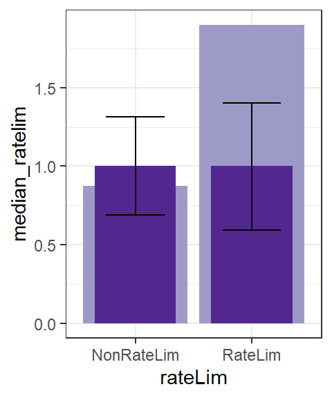

```r
bind_rows(TATTTATT_ratelim2, TATTTATT_nonratelim2) %>%
  mutate(Type = if_else(Type == "Expression matched", "Expression_matched", "ratelim")) %>%
  pivot_wider(id_cols = rateLim, names_from = Type, values_from = c(median, q5, q95)) %>%
  mutate(across(-rateLim, ~ .x/median_Expression_matched)) -> TATTTATT_ratelim2_summary_norm

TATTTATT_ratelim2_summary_norm %>%
  ggplot(aes(x = rateLim, y = median_ratelim)) +
    geom_col(fill = brewer.pal(6,"Purples")[4]) +
    geom_col(aes(y = 1), fill = brewer.pal(6,"Purples")[6], width=0.7) +
    geom_errorbar(aes(ymin = q5_Expression_matched, ymax = q95_Expression_matched), width=0.5) +
    theme_bw() +
    theme(plot.background = element_blank(), panel.background = element_blank())
```

```r
ggsave("Figure_panels/Fig5H_Rate_limiting_TATT_enrich_v2.pdf")
```

## Expression of rate limiting vs non-rate limiting genes

```r
rateLim_genes %>%
  left_join(all_L2FC_norm, by = "Gene") %>%
  pivot_longer(ends_with("zscore"), names_to = "Metric", values_to = "Zscore") %>%
  mutate(Metric = sub("_zscore", "", Metric)) %>%
  mutate(Metric = factor(Metric, levels = c("Nascent", "Stability", "RNA","Ribo"))) -> rateLim_genes_long
```

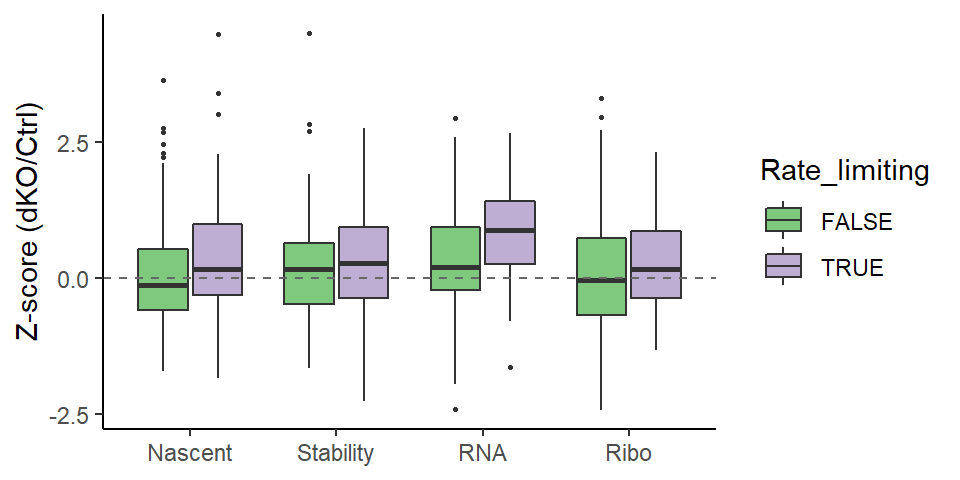

```r
rateLim_genes_long %>%
  ggplot(aes(x = Metric, y= Zscore, fill = Rate_limiting)) +
    geom_boxplot(outlier.size = 0.5) +
    scale_fill_brewer(palette = "Accent") +
    geom_hline(yintercept = 0, linetype = "dashed", colour = "grey40") +
    labs(x = NULL, y = "Z-score (dKO/Ctrl)")
```

```r
ggsave("Figure_panels/Fig5I_RateLimiting_zscores.pdf")
rateLim_genes_long %>%
  group_by(Metric) %>%
  t_test(Zscore ~ Rate_limiting) %>%
  mutate(padj = p.adjust(p, method ="fdr"))
```

| Metric | .y. | group1 | group2 | n1 | n2 | statistic | df | p | padj |
| --- | --- | --- | --- | --- | --- | --- | --- | --- | --- |
| Nascent | Zscore | FALSE | TRUE | 119 | 57 | -1.8919711 | 91.65526 | 0.06170 | 0.1234000 |
| Stability | Zscore | FALSE | TRUE | 119 | 57 | -0.6499892 | 96.20031 | 0.51700 | 0.5170000 |
| RNA | Zscore | FALSE | TRUE | 119 | 57 | -3.0625125 | 119.74924 | 0.00271 | 0.0108400 |
| Ribo | Zscore | FALSE | TRUE | 119 | 57 | -1.3246211 | 128.82361 | 0.18800 | 0.2506667 |

## Table S9 - rate-limiting genes

Export for supplement. This will be combined with the references supporting definition of rate-limiting genes in Excel.

```r
read_tsv("metabolomics/TATT_rateLim2_ID_CLIP_72h_exMatch_expression_matched.txt") %>%
  bind_rows(read_tsv("metabolomics/TATT_nonRateLim2_ID_CLIP_72h_exMatch_expression_matched.txt")) %>%
  filter(grepl("ateLim", Type)) %>%
  select(Gene, nTATTTATT, transcript_id) -> rateLim_TATTTATT
rateLim_genes %>%
  left_join(select(all_L2FC_norm, Gene, Nascent_zscore, Stability_zscore, RNA_zscore, Ribo_zscore)) %>%
  mutate(CLIP_4h = Gene_ID %in% Darnell_4h_3UTR_targets) %>%
  mutate(iCLIP_24h = Gene_ID %in% iCLIP_24h_3UTR_targets) %>%
  mutate(CLIP_72h = Gene_ID %in% Darnell_72h_3UTR_targets) %>%
  left_join(rateLim_TATTTATT, by = c("Gene_ID" = "Gene")) %>%
  write_tsv("Supplementary_tables/TableS9_rateLim.txt")
```

# Figure 6C: glucose measurements

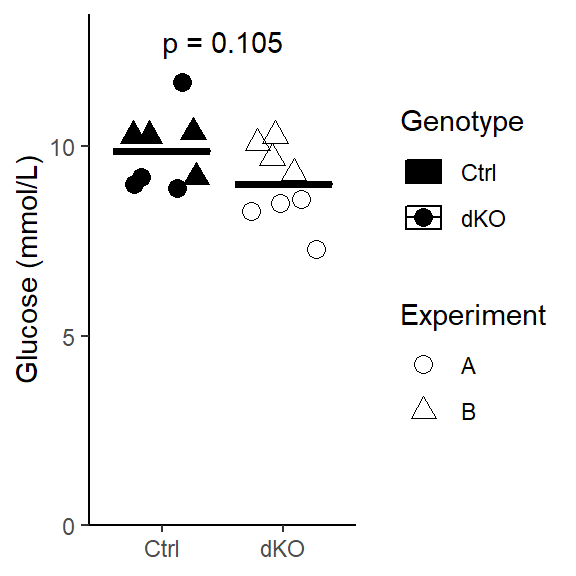

```r
as_tibble(read_pzfx("metabolomics/glucose_measurements/Babraham Project WT vs KO Sups Glucose.pzfx", table = 1)) %>%
  add_column(Experiment = "A") %>%
  bind_rows(add_column(as_tibble(read_pzfx("metabolomics/glucose_measurements/Babraham Project WT vs KO Sups Glucose.pzfx", table = 2)), Experiment= "B")) %>%
  pivot_longer(-Experiment, names_to = "Genotype", values_to = "Glucose_mmolL") %>%
  mutate(Genotype = factor(Genotype, levels= c("WT","KO"), labels = c("Ctrl", "dKO"))) -> glucose_measurements

glucose_measurements %>%
  t_test(Glucose_mmolL ~ Genotype) %>%
  pull(p) -> glucose_ttest

glucose_measurements %>%
  ggplot(aes(x = Genotype, y = Glucose_mmolL, fill = Genotype)) +
    stat_summary(geom = "crossbar", fun = mean, fun.min = mean, fun.max = mean, width = 0.8) +
    geom_point(aes(shape = Experiment), position = position_jitter(height = 0, width = 0.3), size = 3) +
    scale_shape_manual(values = c(21, 24)) +
    coord_cartesian(ylim = c(0,13.5)) +
    scale_y_continuous(expand = c(0,0)) +
    scale_fill_manual(values = c("black", "transparent")) +
    annotate("text", x = 1.5, y= 12.8, label = paste("p =", glucose_ttest)) +
    labs(x= NULL, y = "Glucose (mmol/L)")
```

```r
ggsave("Figure_panels/Fig6C_Glucose_measurements.pdf", useDingbats = F)
```

# Figure 6D: lactate measurements

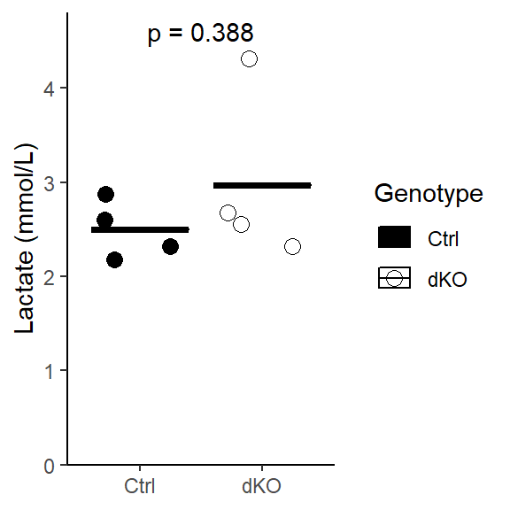

```r
as_tibble(read_pzfx("metabolomics/lactate_measurements/Babraham Project WT vs KO Sups Lactate.pzfx", table = 1)) %>%
  pivot_longer(everything(),names_to = "Genotype", values_to = "Lactate_mmolL") %>%
  mutate(Genotype = factor(Genotype, levels= c("WT","KO"), labels = c("Ctrl", "dKO"))) -> lactate_measurements

lactate_measurements %>%
  t_test(Lactate_mmolL ~ Genotype) %>%
  pull(p) -> lactate_ttest

lactate_measurements %>%
  ggplot(aes(x = Genotype, y = Lactate_mmolL, fill = Genotype)) +
    stat_summary(geom = "crossbar", fun = mean, fun.min = mean, fun.max = mean, width = 0.8) +
    geom_point(shape = 21, position = position_jitter(height = 0, width = 0.3), size = 3) +
    coord_cartesian(ylim = c(0,4.8)) +
    scale_y_continuous(expand = c(0,0)) +
    scale_fill_manual(values = c("black", "transparent")) +
    annotate("text", x = 1.5, y= 4.6, label = paste("p =", lactate_ttest)) +
    labs(x= NULL, y = "Lactate (mmol/L)")
```

```r
ggsave("Figure_panels/Fig6D_Lactate_measurements.pdf", useDingbats = F)
```

# Figures 6B and E: Glucose tracing

Results were collated in Excel: calculated ion counts normalised to internal standard, and overall fractional labelling. Also calculated fractional labelling * norm ion counts, as a measure of labelled ion counts.

```r
read_tsv("metabolomics/glucose_tracing/Norm_ion_counts.txt") %>%
  mutate(Metabolite = sub("_.*", "", Fragment)) %>%
  select(-Fragment) %>%
  pivot_longer(-Metabolite, names_to = "Genotype", values_to = "Relative_abundance") %>%
  mutate(Genotype = factor(sub(" .*", "", sub("HM ", "", Genotype)), levels = c("WT", "KO"), labels = c("Ctrl", "dKO"))) -> Glucose_tracing_ion_counts
read_tsv("metabolomics/glucose_tracing/Fractional_labelling_x_ion_count.txt") %>%
  mutate(Metabolite = sub("_.*", "", Fragment)) %>%
  select(-Fragment) %>%
  pivot_longer(-Metabolite, names_to = "Genotype", values_to = "Relative_abundance") %>%
  mutate(Genotype = factor(sub(" .*", "", sub("HM ", "", Genotype)), levels = c("WT", "KO"), labels = c("Ctrl", "dKO"))) -> Glucose_tracing_labelled_ion_counts
```

## Stats

T-tests (unpaired, 2-tailed) for dKO vs Control, for both total ion counts, and labelled ion counts (ie total ion count * fractional labelling)

```r
Glucose_tracing_ion_counts %>%
  group_by(Metabolite) %>%
  t_test(Relative_abundance ~ Genotype) -> gluc_total_stats
Glucose_tracing_labelled_ion_counts %>%
  group_by(Metabolite) %>%
  t_test(Relative_abundance ~ Genotype) -> gluc_labelled_stats

gluc_total_stats
```

|  | Metabolite | .y. | group1 | group2 | n1 | n2 | statistic | df | p |
| --- | --- | --- | --- | --- | --- | --- | --- | --- | --- |
| 1 | Akg | Relative_abundance | Ctrl | dKO | 4 | 4 | -1.3494928 | 4.368642 | 0.2430 |
| 2 | Ala | Relative_abundance | Ctrl | dKO | 4 | 4 | -1.5452814 | 4.071664 | 0.1960 |
| 3 | Asn | Relative_abundance | Ctrl | dKO | 4 | 4 | -0.8388493 | 3.178674 | 0.4600 |
| 4 | Asp | Relative_abundance | Ctrl | dKO | 4 | 4 | -1.5079208 | 5.277085 | 0.1890 |
| 5 | Cit | Relative_abundance | Ctrl | dKO | 4 | 4 | -0.9406808 | 3.602381 | 0.4060 |
| 6 | Fum | Relative_abundance | Ctrl | dKO | 4 | 4 | -1.8013439 | 3.085493 | 0.1670 |
| 7 | Gln | Relative_abundance | Ctrl | dKO | 4 | 4 | -0.6816571 | 4.675589 | 0.5280 |
| 8 | Glu | Relative_abundance | Ctrl | dKO | 4 | 4 | -1.8038910 | 5.701273 | 0.1240 |
| 9 | Gly | Relative_abundance | Ctrl | dKO | 4 | 4 | -0.1705863 | 4.073238 | 0.8730 |
| 10 | Ile | Relative_abundance | Ctrl | dKO | 4 | 4 | -0.4699209 | 5.355898 | 0.6570 |

[output cut: 10 more lines]

```r
gluc_labelled_stats
```

|  | Metabolite | .y. | group1 | group2 | n1 | n2 | statistic | df | p |
| --- | --- | --- | --- | --- | --- | --- | --- | --- | --- |
| 1 | Akg | Relative_abundance | Ctrl | dKO | 4 | 4 | -0.9890687 | 3.979085 | 0.379 |
| 2 | Ala | Relative_abundance | Ctrl | dKO | 4 | 4 | -1.4774042 | 4.293848 | 0.209 |
| 3 | Asn | Relative_abundance | Ctrl | dKO | 4 | 4 | 1.0811732 | 5.996194 | 0.321 |
| 4 | Asp | Relative_abundance | Ctrl | dKO | 4 | 4 | -1.1879435 | 5.676724 | 0.282 |
| 5 | Cit | Relative_abundance | Ctrl | dKO | 4 | 4 | -1.0100167 | 3.986340 | 0.370 |
| 6 | Fum | Relative_abundance | Ctrl | dKO | 4 | 4 | -1.8659370 | 3.227906 | 0.152 |
| 7 | Gln | Relative_abundance | Ctrl | dKO | 4 | 4 | -0.8044975 | 3.741651 | 0.469 |
| 8 | Glu | Relative_abundance | Ctrl | dKO | 4 | 4 | -1.4259547 | 5.903385 | 0.205 |
| 9 | Gly | Relative_abundance | Ctrl | dKO | 4 | 4 | -1.3296188 | 4.357874 | 0.249 |
| 10 | Ile | Relative_abundance | Ctrl | dKO | 4 | 4 | 0.2263906 | 5.849736 | 0.829 |

[output cut: 10 more lines]

T-test outputs will be added onto figures in Illustrator

## Plot data

Define plotting function (can be used for glutamine tracing later as well):

```r
plot_abundance_with_labelled <- function(metabolite, ion_data = Glucose_tracing_ion_counts, labelled_data = Glucose_tracing_labelled_ion_counts, colour = "black", title = metabolite) {
  ion_data <- filter(ion_data, Metabolite == metabolite)
  labelled_data <- filter(labelled_data, Metabolite == metabolite)

  ion_data %>%
    ggplot(aes(x = Genotype, y = Relative_abundance)) +
      stat_summary(geom = "bar", fun = mean, fill = "transparent", colour = colour, width = 0.7, size = 1) +
      stat_summary(geom = "errorbar", fun.min = mean, fun.max = function(y) {mean(y) + sd(y)}, width= 0.4, colour= colour, size = 1) +
      stat_summary(data = labelled_data, geom = "bar", fun = mean, colour = colour, fill = colour, width = 0.7, size = 1) +
      stat_summary(data = labelled_data, geom = "errorbar", fun.min = mean, fun.max = function(y) {mean(y) + sd(y)}, width= 0.4, colour= colour, size = 1) +
      labs(x = NULL, y = "Relative abundance", title = title) +
      scale_y_continuous(expand = expansion(mult = c(0, 0.2)))
}
```

Plot metabolites we want to show in figures - export PDF for Fig 6B, save the rest into objects to arrange together with glutamine tracing.

```
## adding dummy grobs
```

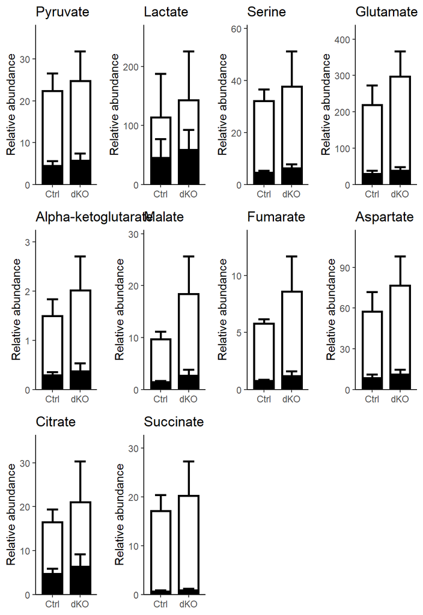

```r
plot_abundance_with_labelled("Pyr", title = "Pyruvate") -> pGlcPyr
plot_abundance_with_labelled("Lac", title = "Lactate") -> pGlcLac
plot_abundance_with_labelled("Ser", title = "Serine") -> pGlcSer
plot_abundance_with_labelled("Glu", title = "Glutamate") -> pGlcGlu
plot_abundance_with_labelled("Akg", title = "Alpha-ketoglutarate") -> pGlcAkg
plot_abundance_with_labelled("Mal", title = "Malate") -> pGlcMal
plot_abundance_with_labelled("Fum", title = "Fumarate") -> pGlcFum
plot_abundance_with_labelled("Asp", title = "Aspartate") -> pGlcAsp
plot_abundance_with_labelled("Cit", title = "Citrate") -> pGlcCit
plot_abundance_with_labelled("Suc", title = "Succinate") -> pGlcSuc

ggarrange(pGlcPyr, pGlcLac, pGlcSer, pGlcGlu, pGlcAkg, pGlcMal, pGlcFum, pGlcAsp, pGlcCit, pGlcSuc, nrow = 3)
```

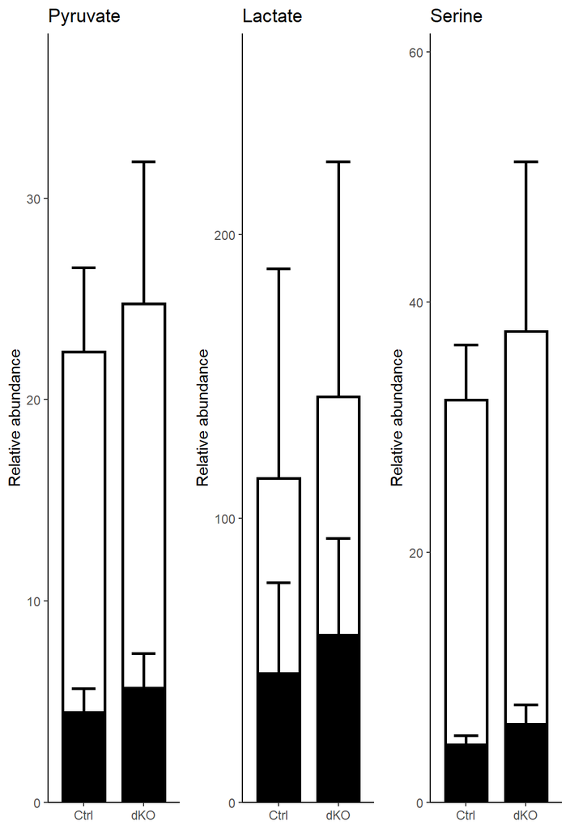

```r
#pdf("Figure_panels/Fig6B_glucLab.pdf", height = 3, width = 5.5)
ggarrange(pGlcPyr, pGlcLac, pGlcSer, nrow = 1)
```

```r
#dev.off()
```

# Figure 6E-F; S4B: glutamine tracing

## Read in data

Read in tables excluding outliers for plotting and stats

```r
read_tsv("metabolomics/glutamine_tracing/Norm_ion_counts_excl_outliers.txt") %>%
  mutate(Metabolite = sub("_.*", "", Fragment)) %>%
  select(-Fragment) %>%
  pivot_longer(-Metabolite, names_to = "Genotype", values_to = "Relative_abundance") %>%
  mutate(Genotype = factor(sub(" ?[0-9]", "", Genotype), levels = c("WT", "KO"), labels = c("Ctrl", "dKO"))) %>%
  na.omit() -> Glutamine_tracing_ion_counts
read_tsv("metabolomics/glutamine_tracing/Fractional_labelling_x_ion_count.txt") %>%
  mutate(Metabolite = sub("_.*", "", Fragment)) %>%
  select(-Fragment) %>%
  pivot_longer(-Metabolite, names_to = "Genotype", values_to = "Relative_abundance") %>%
  mutate(Genotype = factor(sub(" ?[0-9]", "", Genotype), levels = c("WT", "KO"), labels = c("Ctrl", "dKO"))) %>%
  na.omit() -> Glutamine_tracing_labelled_ion_counts
```

## Stats

T-tests (unpaired, 2-tailed) for dKO vs Control, for both total ion counts, and labelled ion counts (ie total ion count * fractional labelling)

```r
Glutamine_tracing_ion_counts %>%
  group_by(Metabolite) %>%
  t_test(Relative_abundance ~ Genotype) -> glut_total_stats
Glutamine_tracing_labelled_ion_counts %>%
  group_by(Metabolite) %>%
  t_test(Relative_abundance ~ Genotype) -> glut_labelled_stats

glut_total_stats
```

|  | Metabolite | .y. | group1 | group2 | n1 | n2 | statistic | df | p |
| --- | --- | --- | --- | --- | --- | --- | --- | --- | --- |
| 1 | Akg | Relative_abundance | Ctrl | dKO | 4 | 4 | -2.31016062 | 3.772468 | 0.086 |
| 2 | Ala | Relative_abundance | Ctrl | dKO | 4 | 4 | -0.66641486 | 3.977841 | 0.542 |
| 3 | Asn | Relative_abundance | Ctrl | dKO | 4 | 4 | -1.78037974 | 5.914121 | 0.126 |
| 4 | Asp | Relative_abundance | Ctrl | dKO | 4 | 4 | -0.06730734 | 5.952472 | 0.949 |
| 5 | Cit | Relative_abundance | Ctrl | dKO | 3 | 4 | -2.01745011 | 2.812483 | 0.143 |
| 6 | Fum | Relative_abundance | Ctrl | dKO | 4 | 4 | -1.27097782 | 5.547170 | 0.254 |
| 7 | Gln | Relative_abundance | Ctrl | dKO | 4 | 3 | -0.50826406 | 2.448921 | 0.653 |
| 8 | Glu | Relative_abundance | Ctrl | dKO | 4 | 4 | -1.56355538 | 3.011337 | 0.216 |
| 9 | Gly | Relative_abundance | Ctrl | dKO | 4 | 4 | -0.54625436 | 3.792068 | 0.615 |
| 10 | Ile | Relative_abundance | Ctrl | dKO | 4 | 4 | 0.41665471 | 3.213696 | 0.703 |

[output cut: 11 more lines]

```r
glut_labelled_stats
```

|  | Metabolite | .y. | group1 | group2 | n1 | n2 | statistic | df | p |
| --- | --- | --- | --- | --- | --- | --- | --- | --- | --- |
| 1 | Akg | Relative_abundance | Ctrl | dKO | 4 | 4 | -2.7579826093 | 5.615697 | 0.0353 |
| 2 | Ala | Relative_abundance | Ctrl | dKO | 4 | 4 | -1.1146078172 | 5.860663 | 0.3090 |
| 3 | Asn | Relative_abundance | Ctrl | dKO | 4 | 4 | -0.6788490725 | 5.995154 | 0.5230 |
| 4 | Asp | Relative_abundance | Ctrl | dKO | 4 | 4 | -0.2637041239 | 5.991204 | 0.8010 |
| 5 | Cit | Relative_abundance | Ctrl | dKO | 3 | 4 | -2.3465384058 | 2.727296 | 0.1090 |
| 6 | Fum | Relative_abundance | Ctrl | dKO | 4 | 4 | -1.4044878205 | 5.618689 | 0.2130 |
| 7 | Gln | Relative_abundance | Ctrl | dKO | 4 | 3 | -0.5375216587 | 2.472220 | 0.6350 |
| 8 | Glu | Relative_abundance | Ctrl | dKO | 4 | 4 | -1.7671028960 | 3.040356 | 0.1740 |
| 9 | Gly | Relative_abundance | Ctrl | dKO | 4 | 4 | 1.7163393987 | 5.366792 | 0.1430 |
| 10 | Ile | Relative_abundance | Ctrl | dKO | 4 | 4 | 0.9694792481 | 3.004376 | 0.4040 |

[output cut: 11 more lines]

T-test outputs will be added onto figures in Illustrator

## Plot data (6E)

```
## adding dummy grobs
```

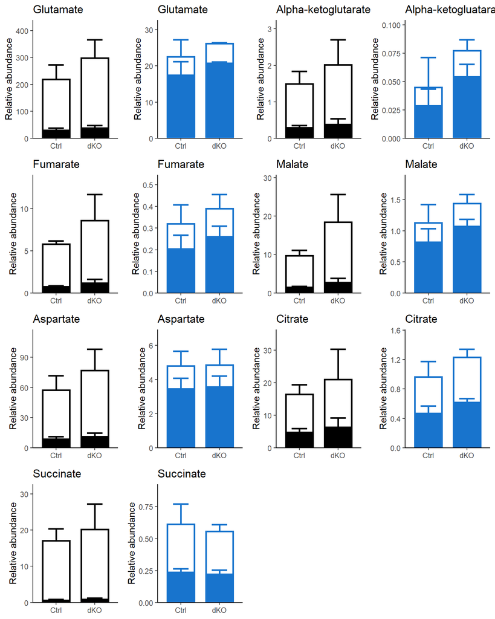

```r
plot_abundance_with_labelled("Glu", ion_data = Glutamine_tracing_ion_counts, labelled_data = Glutamine_tracing_labelled_ion_counts, colour = "dodgerblue3", title = "Glutamate") -> pGluGlu
plot_abundance_with_labelled("Akg", ion_data = Glutamine_tracing_ion_counts, labelled_data = Glutamine_tracing_labelled_ion_counts, colour = "dodgerblue3", title = "Alpha-ketogluatarate") -> pGluAkg
plot_abundance_with_labelled("Mal", ion_data = Glutamine_tracing_ion_counts, labelled_data = Glutamine_tracing_labelled_ion_counts, colour = "dodgerblue3", title = "Malate") -> pGluMal
plot_abundance_with_labelled("Fum", ion_data = Glutamine_tracing_ion_counts, labelled_data = Glutamine_tracing_labelled_ion_counts, colour = "dodgerblue3", title = "Fumarate") -> pGluFum
plot_abundance_with_labelled("Asp", ion_data = Glutamine_tracing_ion_counts, labelled_data = Glutamine_tracing_labelled_ion_counts, colour = "dodgerblue3", title = "Aspartate") -> pGluAsp
plot_abundance_with_labelled("Cit", ion_data = Glutamine_tracing_ion_counts, labelled_data = Glutamine_tracing_labelled_ion_counts, colour = "dodgerblue3", title = "Citrate") -> pGluCit
plot_abundance_with_labelled("Suc", ion_data = Glutamine_tracing_ion_counts, labelled_data = Glutamine_tracing_labelled_ion_counts, colour = "dodgerblue3", title = "Succinate") -> pGluSuc

#pdf("Figure_panels/Fig6E_glucglut_tracing.pdf", height = 10, width = 8)
ggarrange(pGlcGlu, pGluGlu, pGlcAkg, pGluAkg, pGlcFum, pGluFum, pGlcMal, pGluMal, pGlcAsp, pGluAsp, pGlcCit, pGluCit, pGlcSuc, pGluSuc, ncol = 4)
```

```r
#dev.off()
```

## Figure 6F - aKG:succinate ratios

```r
all_metabolomics_LCMS %>%
  select(Metabolite, starts_with("WT"), starts_with("KO")) %>%
  pivot_longer(-Metabolite, names_to = "Sample", values_to = "Abundance") %>%
  pivot_wider(names_from = Metabolite, values_from =Abundance) %>%
  mutate(aKG_succ_ratio = `Alpha-ketoglutarate`/Succinate) %>%
  mutate(Genotype = if_else(grepl("WT", Sample), "Ctrl", "dKO")) %>%
  select(Genotype, aKG_succ_ratio) %>%
  add_column(Dataset ="LCMS") %>%
  bind_rows({
    read_tsv("metabolomics/glucose_tracing/Norm_ion_counts.txt") %>%
      mutate(Metabolite = sub("_.*", "", Fragment)) %>%
      select(-Fragment) %>%
      pivot_longer(-Metabolite, names_to = "Sample", values_to = "Relative_abundance") %>%
      mutate(Sample = gsub(" ", "_", Sample)) %>%
      pivot_wider(names_from = Metabolite, values_from =  Relative_abundance) %>%
      mutate(aKG_succ_ratio = Akg/Suc) %>%
      mutate(Genotype = if_else(grepl("WT", Sample), "Ctrl", "dKO")) %>%
      select(Genotype, aKG_succ_ratio) %>%
      add_column(Dataset = "Glucose_tracing")
  }) %>%
  bind_rows({
    read_tsv("metabolomics/glutamine_tracing/Norm_ion_counts_excl_outliers.txt") %>%
      mutate(Metabolite = sub("_.*", "", Fragment)) %>%
      select(-Fragment) %>%
      pivot_longer(-Metabolite, names_to = "Sample", values_to = "Relative_abundance") %>%
      mutate(Sample = gsub(" ", "", Sample)) %>%
      pivot_wider(names_from = Metabolite, values_from =  Relative_abundance) %>%
      mutate(aKG_succ_ratio = Akg/Suc) %>%
      mutate(Genotype = if_else(grepl("WT", Sample), "Ctrl", "dKO")) %>%
      select(Genotype, aKG_succ_ratio) %>%
      add_column(Dataset = "Glutamine_tracing")
  }) -> aKG_ratios
aKG_ratios %>%
  t_test(aKG_succ_ratio ~ Genotype)
```

|  | .y. | group1 | group2 | n1 | n2 | statistic | df | p |
| --- | --- | --- | --- | --- | --- | --- | --- | --- |
| 1 | aKG_succ_ratio | Ctrl | dKO | 14 | 14 | -3.048575 | 23.25956 | 0.00565 |

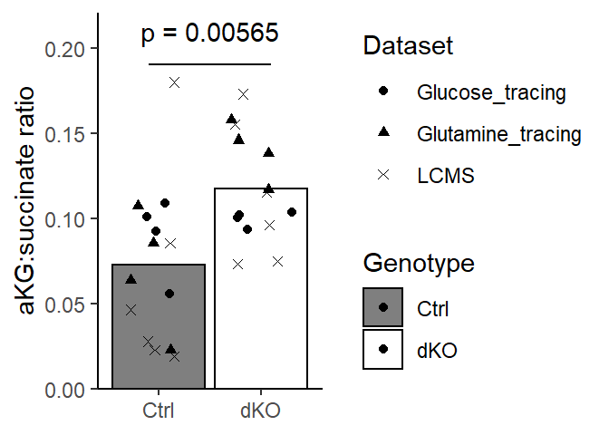

```r
aKG_ratios %>%
  ggplot(aes(x = Genotype, y = aKG_succ_ratio, fill = Genotype)) +
    stat_summary(geom = "bar", fun = mean, colour = "black") +
    geom_jitter(aes(shape = Dataset), width = 0.3) +
    scale_fill_manual(values = c("grey50", "transparent")) +
    scale_shape_manual(values = c(16,17,4)) +
    scale_y_continuous(expand = expansion(mult = c(0,0.05))) +
    annotate("segment", x = 0.9, xend = 2.1, y = 0.19, yend= 0.19) +
    annotate("text", x = 1.5, y = 0.21, label = paste("p =", {
      aKG_ratios %>%
        t_test(aKG_succ_ratio ~ Genotype) %>% pull(p)
    })) +
    labs(x = NULL, y = "aKG:succinate ratio")
```

```r
ggsave("Figure_panels/Fig6F_aKG_succ_ratio.pdf")
```

## MIDs for selected metabolites (S4B)

Will just plot M3-M5 as these are the interesting ones

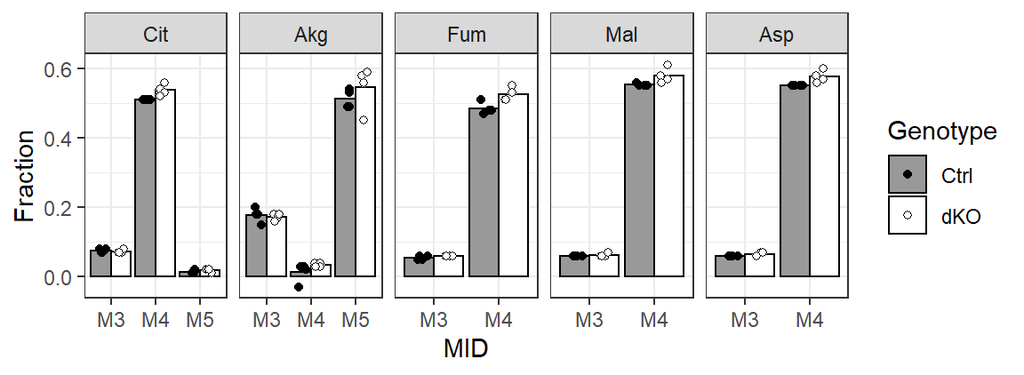

```r
read_tsv("metabolomics/glutamine_tracing/MID_selected.txt") %>%
  rename_with(~ sub(" ", "", .x)) %>%
  pivot_longer(-Isotopomer, names_to = "Sample", values_to = "Fraction") %>%
  mutate(MID = sub(".*\\((.*)\\).*", "\\1", Isotopomer)) %>%
  mutate(Metabolite = sub("_.*", "", Isotopomer)) %>%
  mutate(Genotype = factor(grepl("WT", Sample), levels = c(T,F), labels = c("Ctrl", "dKO"))) %>%
  filter(MID %in% c("M3", "M4", "M5")) %>%
  mutate(Metabolite = factor(Metabolite, levels = c("Cit", "Akg", "Fum", "Mal", "Asp"))) %>%
  ggplot(aes(x = MID, y = Fraction, fill = Genotype, shape = Genotype)) +
    stat_summary(geom = "bar", fun = mean, position = "dodge", colour = "black") +
    geom_point(position = position_jitterdodge()) +
    facet_grid(~Metabolite, scales = "free") +
    theme_bw() +
    scale_fill_manual(values = c("grey60", "white")) +
    scale_shape_manual(values = c(16, 21))
```

```r
ggsave("Figure_panels/FigS4B_TCA_MID.pdf")
```

## Table S11 - tracing experiments

Export data for supplementary table:

Combined glucose and glutamine

```r
read_tsv("metabolomics/glucose_tracing/Norm_ion_counts.txt") %>%
  mutate(Metabolite = sub("_.*", "", Fragment)) %>%
  select(-Fragment) %>%
  left_join({
    read_tsv("metabolomics/glucose_tracing/Fractional_labelling.txt") %>%
  mutate(Metabolite = sub("_.*", "", Fragment)) %>%
  select(-Fragment)
  }, by = "Metabolite", suffix = c("_ion_counts", "_fractional_labelling")) %>%
  left_join({
    read_tsv("metabolomics/glucose_tracing/Fractional_labelling_x_ion_count.txt") %>%
  mutate(Metabolite = sub("_.*", "", Fragment)) %>%
  select(-Fragment) %>%
      rename_with(~ sub("([0-9])", "\\1_ionxfraction", .x))
  }, by = "Metabolite") %>%
  rename_with(~ sub("HM (..) ", "\\1", .x)) %>%
  left_join(select(gluc_total_stats, Metabolite, p), by = "Metabolite") %>%
  left_join(select(gluc_labelled_stats, Metabolite, p), by = "Metabolite", suffix = c("_total", "_labelled")) %>%
  select(Metabolite, ends_with("counts"), p_total, everything()) %>%
  full_join({
    read_tsv("metabolomics/glutamine_tracing/Norm_ion_counts.txt") %>%
      mutate(Metabolite = sub("_.*", "", Fragment)) %>%
      select(-Fragment) %>%
      left_join({
        read_tsv("metabolomics/glutamine_tracing/Fractional_labelling.txt") %>%
      mutate(Metabolite = sub("_.*", "", Fragment)) %>%
      select(-Fragment)
      }, by = "Metabolite", suffix = c("_ion_counts", "_fractional_labelling")) %>%
      left_join({
        read_tsv("metabolomics/glutamine_tracing/Fractional_labelling_x_ion_count.txt") %>%
      mutate(Metabolite = sub("_.*", "", Fragment)) %>%
      select(-Fragment) %>%
          rename_with(~ sub("([0-9])", "\\1_ionxfraction", .x))
      }, by = "Metabolite") %>%
      rename_with(~ sub(" ", "", .x)) %>%
      left_join(select(glut_total_stats, Metabolite, p), by = "Metabolite") %>%
      left_join(select(glut_labelled_stats, Metabolite, p), by = "Metabolite", suffix = c("_total", "_labelled")) %>%
      select(Metabolite, ends_with("counts"), p_total, everything())
  }, by = "Metabolite", suffix = c("_glucose", "_glutamine")) %>%
  write_tsv("Supplementary_tables/TableS11_allLabelling.txt")
```

Means for control and KO in each metric calculated later in Excel.

Results for individual isotopomers also copied directly from origninal table into Excel.

# Figure 7A-C: Glutamine titrations

```r
read_tsv("Th1_diff/glutamine_titration_2.8.21.txt") %>%
  add_column(Experiment = "A") %>%
  bind_rows({
    read_tsv("Th1_diff/glutamine_titration_13.8.21.txt") %>%
      add_column(Experiment = "B")
    }) %>%
  rename_with(~ gsub("\\+", "pos", .x)) %>%
  rename_with(~ gsub("-", "neg", .x)) %>%
  mutate(Glutamine_mM = sub("Th1 (.*) ?mM.*", "\\1", Dataset)) %>%
  mutate(Glutamine_mM = as.factor(sub("_", ".", Glutamine_mM))) %>%
  mutate(Mouse = sub(".*mM_(.*?)_.*", "\\1", Dataset)) %>%
  group_by(Experiment, Glutamine_mM, Mouse) %>%
  summarise(Tbet = mean(Tbet), TbetgMFI = mean(TbetgMFI), EomesgMFI = mean(EomesgMFI), Eomes = mean(Eomes), EomesGzmbPoly = mean(EomesGzmbPoly), GzmbgMFIcons = mean(GzmbgMFIcons), TbetIfng = mean(TbetposIfngpos), EomesGzmb = mean(EomesposGzmbpos), .groups = "drop") %>%
  mutate(Genotype = factor(grepl("WT", Mouse), levels = c(T,F), labels = c("Ctrl", "dKO"))) -> glutamine_titration_summary
```

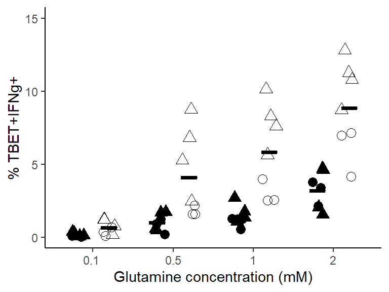

```r
glutamine_titration_summary %>%
  ggplot(aes(x = Glutamine_mM, y = TbetIfng, fill = Genotype, group = Genotype, shape = Experiment)) +
    stat_summary(geom = "crossbar", fun = "mean", fun.min = "mean", fun.max = "mean", position = position_dodge(width = 0.8), width = 0.4) +
    geom_point(position = position_jitterdodge(), size = 3) +
    scale_fill_manual(values = c("black", "transparent")) +
    scale_shape_manual(values = c(21, 24)) +
    coord_cartesian(ylim = c(0,15)) +
    labs(x = "Glutamine concentration (mM)", y = "% TBET+IFNg+") +
    theme(legend.position = "none")
```

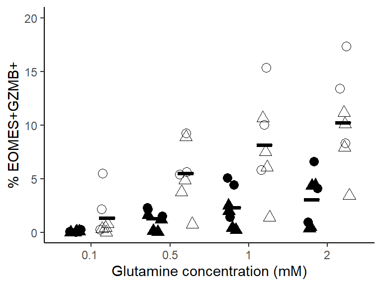

```r
ggsave("Figure_panels/Fig7A_glutamineTh1_TbetIFN.pdf")
glutamine_titration_summary %>%
  ggplot(aes(x = Glutamine_mM, y = EomesGzmbPoly, fill = Genotype, group = Genotype, shape = Experiment)) +
    stat_summary(geom = "crossbar", fun = "mean", fun.min = "mean", fun.max = "mean", position = position_dodge(width = 0.8), width = 0.4) +
    geom_point(position = position_jitterdodge(), size = 3) +
    scale_fill_manual(values = c("black", "transparent")) +
    scale_shape_manual(values = c(21, 24)) +
    coord_cartesian(ylim = c(0,20)) +
    labs(x = "Glutamine concentration (mM)", y = "% EOMES+GZMB+") +
    theme(legend.position = "none")
```

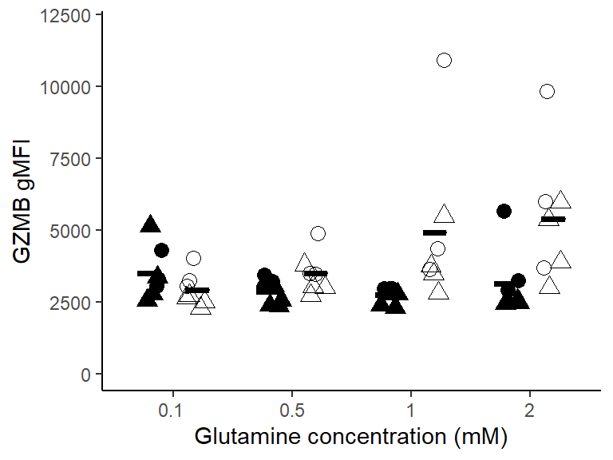

```r
ggsave("Figure_panels/Fig7B_glutamineTh1_EomesGzmb.pdf")
glutamine_titration_summary %>%
  ggplot(aes(x = Glutamine_mM, y = GzmbgMFIcons, fill = Genotype, group = Genotype, shape = Experiment)) +
    stat_summary(geom = "crossbar", fun = "mean", fun.min = "mean", fun.max = "mean", position = position_dodge(width = 0.8), width = 0.4) +
    geom_point(position = position_jitterdodge(), size = 3) +
    scale_fill_manual(values = c("black", "transparent")) +
    scale_shape_manual(values = c(21, 24)) +
    coord_cartesian(ylim = c(0,12000)) +
    labs(x = "Glutamine concentration (mM)", y = "GZMB gMFI") +
    theme(legend.position = "none")
```

```r
ggsave("Figure_panels/Fig7C_glutamineTh1_GzmbMFI.pdf")
```

Kruskal-wallis tests

```r
glutamine_titration_summary %>%
  group_by(Glutamine_mM) %>%
  kruskal_test(TbetIfng ~ Genotype) %>%
  ungroup() %>%
  bind_rows({
    glutamine_titration_summary %>%
      group_by(Glutamine_mM) %>%
      kruskal_test(EomesGzmbPoly ~ Genotype) %>%
      ungroup()
  }) %>%
  bind_rows({
    glutamine_titration_summary %>%
      group_by(Glutamine_mM) %>%
      kruskal_test(GzmbgMFIcons ~ Genotype) %>%
      ungroup()
  }) %>%
  rename(Condition = Glutamine_mM) %>%
  bind_rows({
    glutamine_titration_summary %>%
  group_by(Genotype) %>%
  kruskal_test(TbetIfng ~ Glutamine_mM) %>%
  ungroup() %>%
  bind_rows({
    glutamine_titration_summary %>%
      group_by(Genotype) %>%
      kruskal_test(EomesGzmbPoly ~ Glutamine_mM) %>%
      ungroup()
  }) %>%
  bind_rows({
    glutamine_titration_summary %>%
      group_by(Genotype) %>%
      kruskal_test(GzmbgMFIcons ~ Glutamine_mM) %>%
      ungroup()
  }) %>%
      rename(Condition = Genotype)
  }) %>%
  mutate(padj = p.adjust(p, "fdr"))
```

| Condition | .y. | n | statistic | df | p | method | padj |
| --- | --- | --- | --- | --- | --- | --- | --- |
| 0.1 | TbetIfng | 14 | 5.600063 | 1 | 0.018000 | Kruskal-Wallis | 0.02314286 |
| 0.5 | TbetIfng | 14 | 6.861224 | 1 | 0.008810 | Kruskal-Wallis | 0.01762000 |
| 1 | TbetIfng | 14 | 8.265306 | 1 | 0.004040 | Kruskal-Wallis | 0.01212000 |
| 2 | TbetIfng | 14 | 8.265306 | 1 | 0.004040 | Kruskal-Wallis | 0.01212000 |
| 0.1 | EomesGzmbPoly | 14 | 5.301447 | 1 | 0.021300 | Kruskal-Wallis | 0.02556000 |
| 0.5 | EomesGzmbPoly | 14 | 6.208163 | 1 | 0.012700 | Kruskal-Wallis | 0.01905000 |
| 1 | EomesGzmbPoly | 14 | 6.208163 | 1 | 0.012700 | Kruskal-Wallis | 0.01905000 |
| 2 | EomesGzmbPoly | 14 | 6.861224 | 1 | 0.008810 | Kruskal-Wallis | 0.01762000 |
| 0.1 | GzmbgMFIcons | 14 | 2.551020 | 1 | 0.110000 | Kruskal-Wallis | 0.11647059 |
| 0.5 | GzmbgMFIcons | 14 | 2.975510 | 1 | 0.084500 | Kruskal-Wallis | 0.09506250 |

[output cut: 8 more lines]

## Calculate averages/differences/fold changes

```r
glutamine_titration_summary %>%
  group_by(Glutamine_mM, Genotype) %>%
  summarise(TbetIfng = mean(TbetIfng), EomesGzmbPoly = mean(EomesGzmbPoly), GzmbgMFIcons = mean(GzmbgMFIcons), .groups = "drop") %>%
  pivot_wider(id_cols = Glutamine_mM, names_from = Genotype, values_from = c(TbetIfng,EomesGzmbPoly, GzmbgMFIcons)) %>%
  mutate(TbetIfng_FC = TbetIfng_dKO/TbetIfng_Ctrl) %>%
  mutate(TbetIfng_delta = TbetIfng_dKO-TbetIfng_Ctrl) %>%
  mutate(EomesGzmbPoly_FC = EomesGzmbPoly_dKO/EomesGzmbPoly_Ctrl) %>%
  mutate(EomesGzmbPoly_delta = EomesGzmbPoly_dKO-EomesGzmbPoly_Ctrl) %>%
  mutate(GzmbgMFIcons_FC = GzmbgMFIcons_dKO/GzmbgMFIcons_Ctrl) %>%
  mutate(GzmbgMFIcons_delta = GzmbgMFIcons_dKO-GzmbgMFIcons_Ctrl)
```

| Glutamine_mM | TbetIfng_Ctrl | TbetIfng_dKO | EomesGzmbPoly_Ctrl | EomesGzmbPoly_dKO | GzmbgMFIcons_Ctrl | GzmbgMFIcons_dKO | TbetIfng_FC | TbetIfng_delta | EomesGzmbPoly_FC | EomesGzmbPoly_delta | GzmbgMFIcons_FC | GzmbgMFIcons_delta |
| --- | --- | --- | --- | --- | --- | --- | --- | --- | --- | --- | --- | --- |
| 0.1 | 0.1595000 | 0.6496429 | 0.081000 | 1.355714 | 3502.143 | 2922.429 | 4.072996 | 0.4901429 | 16.737213 | 1.274714 | 0.8344687 | -579.7143 |
| 0.5 | 0.9864286 | 4.0921429 | 1.290786 | 5.515000 | 2865.929 | 3482.714 | 4.148443 | 3.1057143 | 4.272591 | 4.224214 | 1.2152132 | 616.7857 |
| 1 | 1.4264286 | 5.8264286 | 2.305929 | 8.120000 | 2737.500 | 4917.929 | 4.084627 | 4.4000000 | 3.521358 | 5.814071 | 1.7965036 | 2180.4286 |
| 2 | 3.1807143 | 8.8407143 | 3.052143 | 10.240000 | 3119.929 | 5392.929 | 2.779475 | 5.6600000 | 3.355020 | 7.187857 | 1.7285423 | 2273.0000 |

# Figure 7D-E: aKG titrations

In the second experiment, there was an issue with the original genotyping - samples labelled ko1 and ko4 are actually controls.

```r
read_tsv("Th1_diff/aKG_titration_23.11.21.txt") %>%
  add_column(Experiment = "A") %>%
  bind_rows({
    read_tsv("Th1_diff/aKG_titration_13.12.21.txt") %>%
      add_column(Experiment = "B") %>%
      mutate(Dataset = sub("ko1", "wt6", sub("ko4", "wt7", Dataset)))
    }) %>%
  rename_with(~ gsub("\\+", "pos", .x)) %>%
  rename_with(~ gsub("-", "neg", .x)) %>%
  mutate(aKG_mM = sub("No Glutamine_(.*) aKG.*", "\\1", Dataset)) %>%
  mutate(aKG_mM = as.factor(sub(" mM", "", sub("No", "0", sub("_", ".", aKG_mM))))) %>%
  mutate(Mouse = sub(".*aKG (.*?)_.*", "\\1", Dataset)) %>%
  group_by(Experiment, aKG_mM, Mouse) %>%
  summarise(EomesGzmbPoly = mean(EomesGzmbPoly), GzmbgMFIcons = mean(GzmbgMFIcons), TbetIfng = mean(TbetposIfngpos), EomesGzmb = mean(EomesposGzmbpos), .groups = "drop") %>%
  mutate(Genotype = factor(grepl("wt", Mouse), levels = c(T,F), labels = c("Ctrl", "dKO"))) -> aKG_titration_summary
```

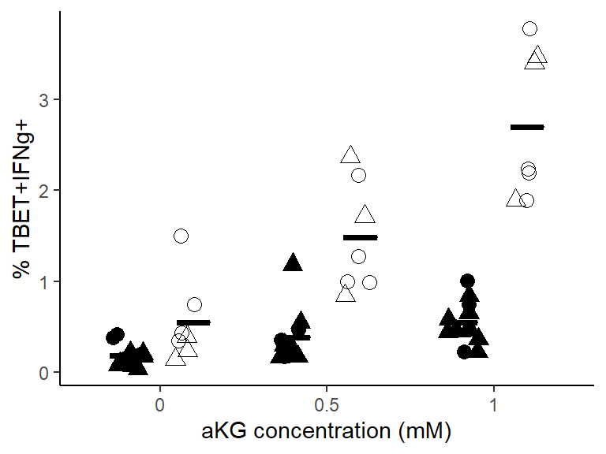

```r
aKG_titration_summary %>%
  ggplot(aes(x = aKG_mM, y = TbetIfng, fill = Genotype, group = Genotype, shape = Experiment)) +
    stat_summary(geom = "crossbar", fun = "mean", fun.min = "mean", fun.max = "mean", position = position_dodge(width = 0.8), width = 0.4) +
    geom_point(position = position_jitterdodge(), size = 3) +
    scale_fill_manual(values = c("black", "transparent")) +
    scale_shape_manual(values = c(21, 24)) +
    #coord_cartesian(ylim = c(0,15)) +
    labs(x = "aKG concentration (mM)", y = "% TBET+IFNg+") +
    theme(legend.position = "none")
```

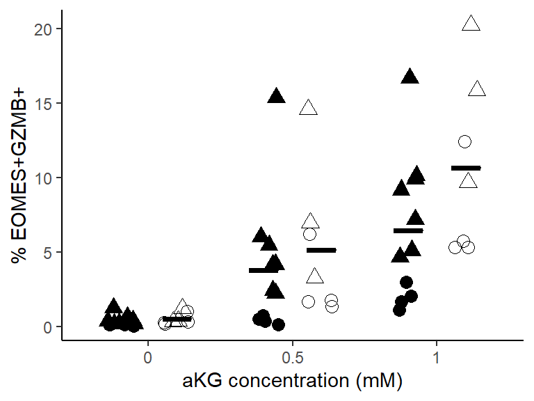

```r
ggsave("Figure_panels/Fig7D_aKGTh1_TbetIFN.pdf")
aKG_titration_summary %>%
  ggplot(aes(x = aKG_mM, y = EomesGzmbPoly, fill = Genotype, group = Genotype, shape = Experiment)) +
    stat_summary(geom = "crossbar", fun = "mean", fun.min = "mean", fun.max = "mean", position = position_dodge(width = 0.8), width = 0.4) +
    geom_point(position = position_jitterdodge(), size = 3) +
    scale_fill_manual(values = c("black", "transparent")) +
    scale_shape_manual(values = c(21, 24)) +
    #coord_cartesian(ylim = c(0,20)) +
    labs(x = "aKG concentration (mM)", y = "% EOMES+GZMB+") +
    theme(legend.position = "none")
```

```r
ggsave("Figure_panels/Fig7E_aKGTh1_EomesGzmb.pdf")
```

Kruskal-wallis tests

```r
aKG_titration_summary %>%
  group_by(aKG_mM) %>%
  kruskal_test(TbetIfng ~ Genotype) %>%
  ungroup() %>%
  bind_rows({
    aKG_titration_summary %>%
      group_by(aKG_mM) %>%
      kruskal_test(EomesGzmbPoly ~ Genotype) %>%
      ungroup()
  }) %>%
  rename(Condition = aKG_mM) %>%
  bind_rows({
    aKG_titration_summary %>%
  group_by(Genotype) %>%
  kruskal_test(TbetIfng ~ aKG_mM) %>%
  ungroup() %>%
  bind_rows({
    aKG_titration_summary %>%
      group_by(Genotype) %>%
      kruskal_test(EomesGzmbPoly ~ aKG_mM) %>%
      ungroup()
  }) %>%
      rename(Condition = Genotype)
  }) %>%
  mutate(padj = p.adjust(p, "fdr"))
```

| Condition | .y. | n | statistic | df | p | method | padj |
| --- | --- | --- | --- | --- | --- | --- | --- |
| 0 | TbetIfng | 18 | 5.7600820 | 1 | 0.016400 | Kruskal-Wallis | 0.023428571 |
| 0.5 | TbetIfng | 18 | 10.3369788 | 1 | 0.001300 | Kruskal-Wallis | 0.002166667 |
| 1 | TbetIfng | 18 | 12.1704545 | 1 | 0.000486 | Kruskal-Wallis | 0.001494000 |
| 0 | EomesGzmbPoly | 18 | 1.8474294 | 1 | 0.174000 | Kruskal-Wallis | 0.193333333 |
| 0.5 | EomesGzmbPoly | 18 | 0.7402597 | 1 | 0.390000 | Kruskal-Wallis | 0.390000000 |
| 1 | EomesGzmbPoly | 18 | 2.8072454 | 1 | 0.093800 | Kruskal-Wallis | 0.117250000 |
| Ctrl | TbetIfng | 33 | 14.4370261 | 2 | 0.000733 | Kruskal-Wallis | 0.001494000 |
| dKO | TbetIfng | 21 | 14.3989604 | 2 | 0.000747 | Kruskal-Wallis | 0.001494000 |
| Ctrl | EomesGzmbPoly | 33 | 17.7656782 | 2 | 0.000139 | Kruskal-Wallis | 0.001390000 |
| dKO | EomesGzmbPoly | 21 | 14.7161410 | 2 | 0.000637 | Kruskal-Wallis | 0.001494000 |

# Figure 7F - transcriptomic read counts

Make tibble that contains normalised counts for RNA-seq, Ribo-seq and 4SU

```r
norm_counts_RNA %>%
  left_join(norm_counts_Ribo) %>%
  left_join(norm_counts_4sU) %>%
  select(-ends_with("mean")) %>%
  column_to_rownames("Gene") %>%
  t() %>%
  as_tibble(rownames = "Sample") %>%
  mutate(Dataset = case_when(
    grepl("^RF", Sample) ~ "Ribo",
    grepl("^RNA", Sample) ~ "RNA",
    TRUE ~ "4sU"
  )) %>%
  mutate(Dataset = factor(Dataset, levels = c("4sU", "RNA", "Ribo"))) %>%
  mutate(Genotype = if_else(grepl("KO", Sample), "dKO", "Ctrl")) ->
    all_norm_counts_t
```

Define function for plotting counts

```r
plot_gene_counts <- function(Gene) {
  all_norm_counts_t %>%
    ggplot(aes(x = Dataset, y = get(Gene), shape = Genotype, fill = Genotype)) +
      stat_summary(geom = "bar", fun = "mean", position = "dodge", width = 0.8, colour = "black") +
      geom_point(position = position_jitterdodge(jitter.width = 0.3, dodge.width = 0.8), size = 2) +
      labs(x = NULL, y = paste(Gene, "normalised read counts")) +
      scale_shape_manual(values = c(16, 1)) +
      scale_fill_manual(values = c("grey60", "transparent")) +
      scale_y_continuous(expand = expansion(mult  = c(0,0.1)))
}
```

Plot for genes of interest

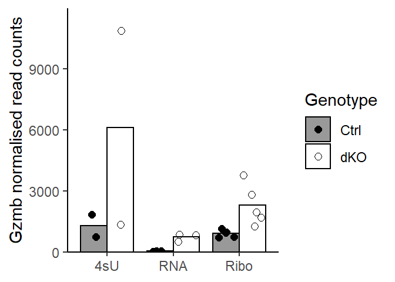

```r
plot_gene_counts("Gzmb")
```

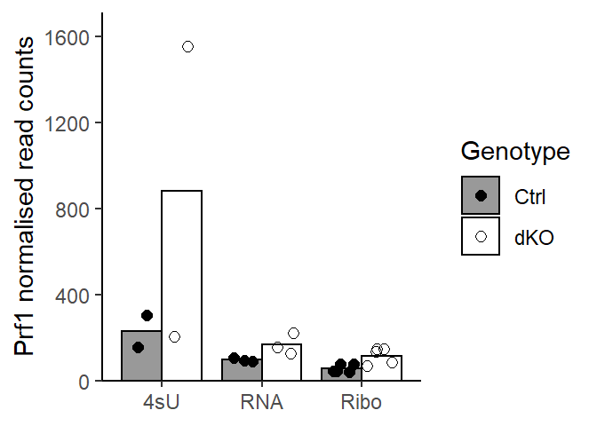

```r
ggsave("Figure_panels/Fig7F_Gzmb.pdf", useDingbats = F)
plot_gene_counts("Prf1")
```

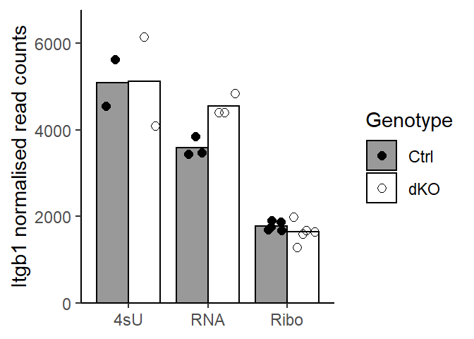

```r
ggsave("Figure_panels/Fig7F_Prf1.pdf", useDingbats = F)
plot_gene_counts("Itgb1")
```

```r
ggsave("Figure_panels/Fig7F_Itgb1.pdf", useDingbats = F)
res_RNA %>%
  filter(Gene %in% c("Gzmb", "Prf1", "Itgb1"))
```

| Gene | baseMean | log2FoldChange | lfcSE | stat | pvalue | padj | Cytokine |
| --- | --- | --- | --- | --- | --- | --- | --- |
| Itgb1 | 4071.1929 | 0.3274040 | 0.06315781 | 5.183789 | 2.174232e-07 | 2.207901e-06 | FALSE |
| Prf1 | 132.9539 | 0.5152825 | 0.14722845 | 3.494921 | 4.742024e-04 | 2.156819e-03 | FALSE |
| Gzmb | 387.0975 | 1.7012414 | 0.15489040 | 11.854015 | 2.051214e-32 | 2.938811e-30 | FALSE |

```r
res_Ribo %>%
  filter(Gene %in% c("Gzmb", "Prf1", "Itgb1"))
```

| Gene | baseMean | log2FoldChange | lfcSE | stat | pvalue | padj | Cytokine |
| --- | --- | --- | --- | --- | --- | --- | --- |
| Itgb1 | 1710.76319 | -0.09680011 | 0.08330724 | -1.174161 | 2.403306e-01 | 5.922605e-01 | FALSE |
| Prf1 | 86.84415 | 0.45763723 | 0.10738351 | 4.199347 | 2.676863e-05 | 1.768164e-03 | FALSE |
| Gzmb | 1603.69169 | 0.80085741 | 0.10482522 | 7.436468 | 1.034132e-13 | 5.737879e-11 | FALSE |

```r
res_4sU %>%
  filter(Gene %in% c("Gzmb", "Prf1", "Itgb1"))
```

| Gene | baseMean | log2FoldChange | lfcSE | stat | pvalue | padj | Cytokine |
| --- | --- | --- | --- | --- | --- | --- | --- |
| Itgb1 | 5105.6549 | -0.003299709 | 0.10079472 | -0.06250457 | 0.9501610 | 0.9996348 | FALSE |
| Prf1 | 554.5799 | 0.100668399 | 0.05096076 | 1.61650988 | 0.1059841 | 0.9996348 | FALSE |
| Gzmb | 3706.6407 | 0.136716835 | 0.05564933 | 2.20913713 | 0.0271651 | 0.6691339 | FALSE |

Stats from DESeq2 added in Illustrator

# Figure 7G - Th1 heatmap

Also include TFs that came up in the CD8 manuscript

```r
tibble(Gene = c("Tbx21", "Eomes", "Runx3", "Stat1", "Stat4", "Irf4", "Irf8", "Notch1", "Notch2", "Nfatc1", "Nfatc2", "Nfatc3", "Jun", "Fos", "Mitf", "Hopx", "Prdm1", "Nfkb1", "Nfkb2", "Rel")) %>%
  mutate(Nascent_zscore = all_L2FC_norm$Nascent_zscore[match(Gene, all_L2FC_norm$Gene)]) %>%
  mutate(Stability_zscore = all_L2FC_norm$Stability_zscore[match(Gene, all_L2FC_norm$Gene)]) %>%
  mutate(RNA_zscore = all_L2FC_norm$RNA_zscore[match(Gene, all_L2FC_norm$Gene)]) %>%
  mutate(Ribo_zscore = all_L2FC_norm$Ribo_zscore[match(Gene, all_L2FC_norm$Gene)]) %>%
    mutate(Nascent_padj = res_4sU$padj[match(Gene, res_4sU$Gene)]) %>%
    mutate(Stability_padj = Stability_differences$fdr.value[match(Gene, Stability_differences$Gene)]) %>%
    mutate(RNA_padj = res_RNA$padj[match(Gene, res_RNA$Gene)]) %>%
    mutate(Ribo_padj = res_Ribo$padj[match(Gene, res_Ribo$Gene)]) %>%
      mutate(Nascent_pval = res_4sU$pvalue[match(Gene, res_4sU$Gene)]) %>%
      mutate(Stability_pval = Stability_differences$p.value[match(Gene, Stability_differences$Gene)]) %>%
      mutate(RNA_pval = res_RNA$pvalue[match(Gene, res_RNA$Gene)]) %>%
      mutate(Ribo_pval = res_Ribo$pvalue[match(Gene, res_Ribo$Gene)]) %>%
        mutate(RNA_Ctrl_expression = norm_counts_RNA$Ctrl_mean[match(Gene, norm_counts_RNA$Gene)]) %>%
          mutate(Darnell_72h_3UTR_sum_n90 = if_else(Gene %in% CLIP_72h_3UTR_sum$Gene_name, CLIP_72h_3UTR_sum$sum_3UTR_72h_n90[match(Gene, CLIP_72h_3UTR_sum$Gene_name)], 0)) %>%
          mutate(iCLIP_24h_3UTR_sum_n90 = if_else(Gene %in% iCLIP_24h_3UTR_sum$Gene_name, iCLIP_24h_3UTR_sum$sum_3UTR_24h_n90[match(Gene, iCLIP_24h_3UTR_sum$Gene_name)], 0)) %>%
          mutate(Darnell_4h_3UTR_sum_n90 = if_else(Gene %in% CLIP_4h_3UTR_sum$Gene_name, CLIP_4h_3UTR_sum$sum_3UTR_4h_n90[match(Gene, CLIP_4h_3UTR_sum$Gene_name)], 0)) -> Th1_hm

summary(Th1_hm)
```

```
##      Gene           Nascent_zscore     Stability_zscore     RNA_zscore
##  Length:20          Min.   :-2.72583   Min.   :-1.62415   Min.   :-1.0401
##  Class :character   1st Qu.:-0.09466   1st Qu.:-0.57636   1st Qu.:-0.4495
##  Mode  :character   Median : 0.40027   Median :-0.01141   Median : 0.1435
##                     Mean   : 0.55686   Mean   :-0.10218   Mean   : 0.4147
##                     3rd Qu.: 1.23696   3rd Qu.: 0.44842   3rd Qu.: 0.9160
##                     Max.   : 3.22712   Max.   : 1.43772   Max.   : 3.3157
##   Ribo_zscore       Nascent_padj    Stability_padj      RNA_padj
##  Min.   :-1.5700   Min.   :0.1395   Min.   :0.4996   Min.   :0.0000000
##  1st Qu.: 0.1646   1st Qu.:0.9939   1st Qu.:0.4996   1st Qu.:0.0006602
##  Median : 1.0370   Median :0.9996   Median :0.4996   Median :0.0257079
##  Mean   : 1.0386   Mean   :0.8587   Mean   :0.4996   Mean   :0.1977589
##  3rd Qu.: 1.7010   3rd Qu.:0.9996   3rd Qu.:0.4996   3rd Qu.:0.2816802
##  Max.   : 5.7117   Max.   :0.9996   Max.   :0.4996   Max.   :0.9130369
##    Ribo_padj       Nascent_pval      Stability_pval       RNA_pval
##  Min.   :0.0000   Min.   :0.001692   Min.   :0.05217   Min.   :0.0000000
##  1st Qu.:0.0836   1st Qu.:0.095915   1st Qu.:0.19104   1st Qu.:0.0001259
##  Median :0.3492   Median :0.362727   Median :0.28595   Median :0.0086830
##  Mean   :0.3659   Mean   :0.430409   Mean   :0.28370   Mean   :0.1487348
##  3rd Qu.:0.5594   3rd Qu.:0.717511   3rd Qu.:0.36517   3rd Qu.:0.1636952
##  Max.   :0.9724   Max.   :0.996650   Max.   :0.47876   Max.   :0.8611543
##    Ribo_pval       RNA_Ctrl_expression Darnell_72h_3UTR_sum_n90
##  Min.   :0.00000   Min.   : 5.169      Min.   : 0.0000
##  1st Qu.:0.00479   1st Qu.: 7.617      1st Qu.: 0.0000
##  Median :0.07511   Median :11.229      Median : 0.6618
##  Mean   :0.17329   Mean   :10.477      Mean   : 1.8395
##  3rd Qu.:0.20951   3rd Qu.:12.675      3rd Qu.: 1.7708
##  Max.   :0.91235   Max.   :15.209      Max.   :13.8848
##  iCLIP_24h_3UTR_sum_n90 Darnell_4h_3UTR_sum_n90
##  Min.   :0.0000         Min.   : 0.00000
##  1st Qu.:0.0000         1st Qu.: 0.02727
##  Median :0.5357         Median : 0.11818
##  Mean   :1.2464         Mean   : 1.92727
##  3rd Qu.:1.0536         3rd Qu.: 1.94545
##  Max.   :6.2143         Max.   :16.85455
```

Range of 0-20 for CLIP and 5-16 for expression as for metabolism. Max Ribo z score is outside the 4.6 limit set for other heatmaps, but fine to use the same colour scale breaks for the main heatmap since any outliers will just be displayed with max.

```r
Th1_hm %>%
  add_row(Gene ="dummy", Nascent_zscore = 0, Stability_zscore = 0, RNA_zscore =0, Ribo_zscore =0, Darnell_4h_3UTR_sum_n90 = 20, Darnell_72h_3UTR_sum_n90 =20, iCLIP_24h_3UTR_sum_n90 =20, RNA_Ctrl_expression = 5) %>%
  add_row(Gene ="dummy2", Nascent_zscore = 0, Stability_zscore = 0, RNA_zscore =0, Ribo_zscore =0, Darnell_4h_3UTR_sum_n90 = 0, Darnell_72h_3UTR_sum_n90 =0, iCLIP_24h_3UTR_sum_n90 =0, RNA_Ctrl_expression = 16) -> Th1_hm
```

Separate out into z scores for main heatmap, annotations, and p values - convert these to stars depending on significance.

Symmetrical breaks for main colour scale will be the same as those used for TFs.

For CLIP annotations - log transform values.

```r
Th1_hm %>%
  select(1:5) %>%
  column_to_rownames("Gene") ->
    Th1_zscores


Th1_hm %>%
  mutate(Nascent_sig = case_when(
    Nascent_padj < 0.05 ~ "***",
    Nascent_pval < 0.05 ~ "**",
    Nascent_pval < 0.1 ~ "*",
    TRUE ~ ""
  )) %>%
  mutate(Stability_sig = case_when(
    Stability_padj < 0.05 ~ "***",
    Stability_pval < 0.05 ~ "**",
    Stability_pval < 0.1 ~ "*",
    TRUE ~ ""
  )) %>%
  mutate(RNA_sig = case_when(
    RNA_padj < 0.05 ~ "***",
    RNA_pval < 0.05 ~ "**",
    RNA_pval < 0.1 ~ "*",
    TRUE ~ ""
  )) %>%
  mutate(Ribo_sig = case_when(
    Ribo_padj < 0.05 ~ "***",
    Ribo_pval < 0.05 ~ "**",
    Ribo_pval < 0.1 ~ "*",
    TRUE ~ ""
  )) %>%
  select(Gene, ends_with("sig")) %>%
  column_to_rownames("Gene") -> Th1_sig


Th1_hm %>%
  select(Gene, RNA_Ctrl_expression, ends_with("n90")) %>%
  mutate_at(vars(ends_with("n90")), function(x) log2((10*x)+1)) %>%
  column_to_rownames("Gene") -> Th1_annotations
```

Plot heatmap:

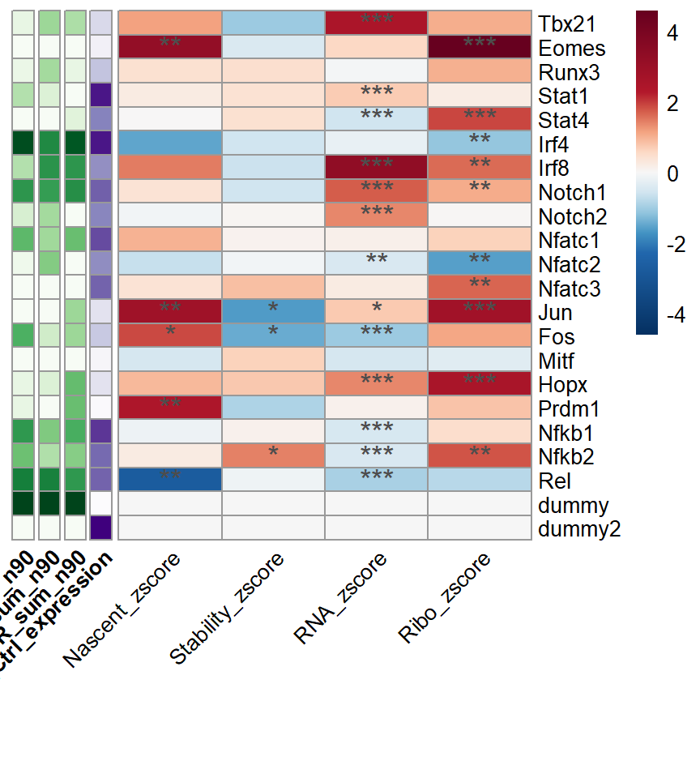

```r
#pdf("Figure_panels/Fig7G_Th1hm.pdf", height = 5, width = 4.5)
Th1_zscores %>%
  pheatmap(cluster_rows = F,
           cluster_cols = F,
           breaks = sym_breaks,
           angle_col = 45,
           fontsize_row = 10,
           color = c(colorRampPalette(colors = brewer.pal(11,"RdBu")[11:10])(100),colorRampPalette(colors = brewer.pal(11,"RdBu")[10:2])(200),colorRampPalette(colors = brewer.pal(11,"RdBu")[2:1])(100)),
           display_numbers = Th1_sig,
           annotation_row = Th1_annotations,
           annotation_colors = list(
             Darnell_72h_3UTR_sum_n90 = brewer.pal(9, "Greens"),
             Darnell_4h_3UTR_sum_n90 = brewer.pal(9, "Greens"),
             iCLIP_24h_3UTR_sum_n90 = brewer.pal(9, "Greens"),
             RNA_Ctrl_expression = brewer.pal(9, "Purples")
           ),
           fontsize_number = 14,
           annotation_legend = F)
```

```r
#dev.off()
```

# Figure 7H-K: Influenza

There are 3 experiments for this. KC36 does not include TNF so can only plot IFNg and granzyme, for the others can include IFNg vs TNF and TNF MFI as well.

```r
read_tsv("Influenza/KC27_final.txt") %>%
  mutate(Genotype = factor(sub("[0-9]", "", Sample), levels = c("WT","KO"))) -> influenza_KC27
read_tsv("Influenza/KC36_final.txt") %>%
  mutate(Genotype = factor(sub("[0-9]", "", Sample), levels = c("WT","K"), labels = c("WT","KO"))) -> influenza_KC36
read_tsv("Influenza/KC45_final.txt") %>%
  mutate(Genotype = factor(sub("[0-9]", "", Sample), levels = c("WT","K"), labels = c("WT","KO"))) -> influenza_KC45
```

## IFN or TNF single positive

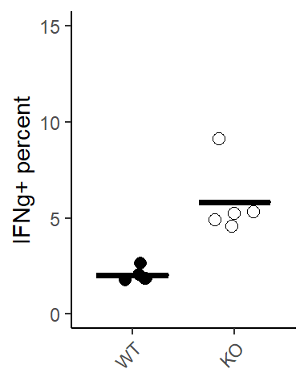

```r
influenza_KC27 %>%
  ggplot(aes(x = Genotype, y = IFNg_total, shape = Genotype)) +
    stat_summary(geom = "crossbar", fun = "mean", fun.min = "mean", fun.max = "mean", width=0.7, colour = "black") +
    geom_jitter(height = 0, width=0.2, size = 2.5) +
    scale_shape_manual(values = c(16, 1)) +
    theme(legend.position = "none") +
    theme(axis.text.x = element_text(angle = 45, hjust = 1)) +
    coord_cartesian(ylim = c(0,15)) +
    labs(x = NULL, y = "IFNg+ percent")
```

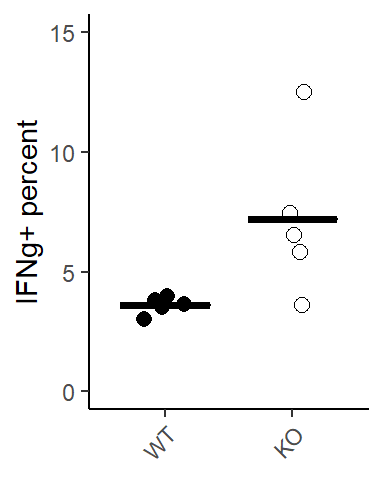

```r
influenza_KC36 %>%
  ggplot(aes(x = Genotype, y = IFNgpos, shape = Genotype)) +
    stat_summary(geom = "crossbar", fun = "mean", fun.min = "mean", fun.max = "mean", width=0.7, colour = "black") +
    geom_jitter(height = 0, width=0.2, size = 2.5) +
    scale_shape_manual(values = c(16, 1)) +
    theme(legend.position = "none") +
    theme(axis.text.x = element_text(angle = 45, hjust = 1)) +
    coord_cartesian(ylim = c(0,15)) +
    labs(x = NULL, y = "IFNg+ percent")
```

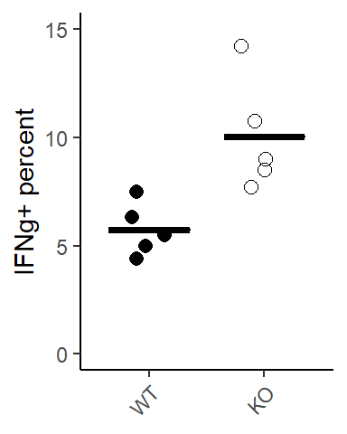

```r
influenza_KC45 %>%
  ggplot(aes(x = Genotype, y = IFNg_total, shape = Genotype)) +
    stat_summary(geom = "crossbar", fun = "mean", fun.min = "mean", fun.max = "mean", width=0.7, colour = "black") +
    geom_jitter(height = 0, width=0.2, size = 2.5) +
    scale_shape_manual(values = c(16, 1)) +
    theme(legend.position = "none") +
    theme(axis.text.x = element_text(angle = 45, hjust = 1)) +
    coord_cartesian(ylim = c(0,15)) +
    labs(x = NULL, y = "IFNg+ percent")
```

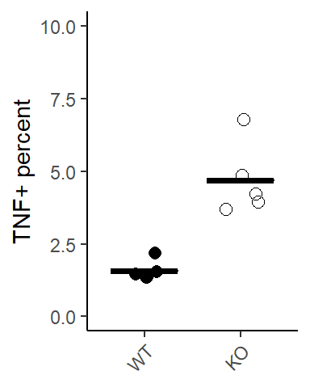

```r
ggsave("Figure_panels/Fig7J_IFNpercent_KC45flu.pdf", useDingbats = F)
influenza_KC27 %>%
  ggplot(aes(x = Genotype, y = TNF_total, shape = Genotype)) +
    stat_summary(geom = "crossbar", fun = "mean", fun.min = "mean", fun.max = "mean", width=0.7, colour = "black") +
    geom_jitter(height = 0, width=0.2, size = 2.5) +
    scale_shape_manual(values = c(16, 1)) +
    theme(legend.position = "none") +
    theme(axis.text.x = element_text(angle = 45, hjust = 1)) +
    coord_cartesian(ylim = c(0,10)) +
    labs(x = NULL, y = "TNF+ percent")
```

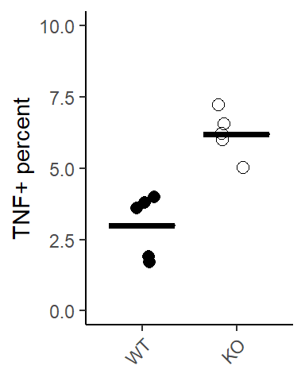

```r
influenza_KC45 %>%
  ggplot(aes(x = Genotype, y = TNF_total, shape = Genotype)) +
    stat_summary(geom = "crossbar", fun = "mean", fun.min = "mean", fun.max = "mean", width=0.7, colour = "black") +
    geom_jitter(height = 0, width=0.2, size = 2.5) +
    scale_shape_manual(values = c(16, 1)) +
    theme(legend.position = "none") +
    theme(axis.text.x = element_text(angle = 45, hjust = 1)) +
    coord_cartesian(ylim = c(0,10)) +
    labs(x = NULL, y = "TNF+ percent")
```

Pattern is always the same for IFNg+ (and TNF+) though numbers vary - best to show one as representative. All plots for manuscript figures coming from KC45

T-tests for IFNg+ or TNF+

```r
t.test(IFNg_total ~ Genotype, influenza_KC27)
```

```
##
##  Welch Two Sample t-test
##
## data:  IFNg_total by Genotype
## t = -4.4902, df = 4.2837, p-value = 0.009306
## alternative hypothesis: true difference in means between group WT and group KO is not equal to 0
## 95 percent confidence interval:
##  -6.079907 -1.508093
## sample estimates:
## mean in group WT mean in group KO
##            2.038            5.832
```

```r
t.test(IFNgpos ~ Genotype, influenza_KC36)
```

```
##
##  Welch Two Sample t-test
##
## data:  IFNgpos by Genotype
## t = -2.4236, df = 4.1051, p-value = 0.07085
## alternative hypothesis: true difference in means between group WT and group KO is not equal to 0
## 95 percent confidence interval:
##  -7.6615122  0.4815122
## sample estimates:
## mean in group WT mean in group KO
##             3.59             7.18
```

```r
t.test(IFNg_total ~ Genotype, influenza_KC45)
```

```
##
##  Welch Two Sample t-test
##
## data:  IFNg_total by Genotype
## t = -3.3677, df = 5.6659, p-value = 0.01646
## alternative hypothesis: true difference in means between group WT and group KO is not equal to 0
## 95 percent confidence interval:
##  -7.452134 -1.127866
## sample estimates:
## mean in group WT mean in group KO
##             5.74            10.03
```

```r
t.test(TNF_total ~ Genotype, influenza_KC27)
```

```
##
##  Welch Two Sample t-test
##
## data:  TNF_total by Genotype
## t = -5.4134, df = 4.6233, p-value = 0.00369
## alternative hypothesis: true difference in means between group WT and group KO is not equal to 0
## 95 percent confidence interval:
##  -4.632665 -1.599335
## sample estimates:
## mean in group WT mean in group KO
##            1.566            4.682
```

```r
t.test(TNF_total ~ Genotype, influenza_KC45)
```

```
##
##  Welch Two Sample t-test
##
## data:  TNF_total by Genotype
## t = -5.2339, df = 7.3019, p-value = 0.001056
## alternative hypothesis: true difference in means between group WT and group KO is not equal to 0
## 95 percent confidence interval:
##  -4.636591 -1.767409
## sample estimates:
## mean in group WT mean in group KO
##            3.000            6.202
```

Significant in all but IFN in KC36 (almost there for that)